# IE360_Project_RCodes_Group28

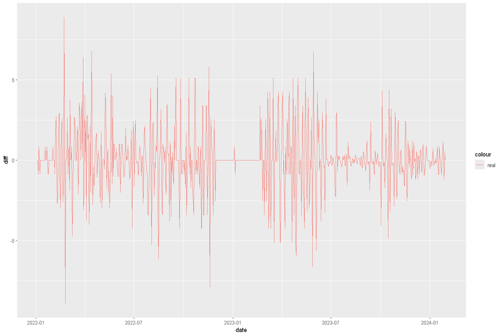

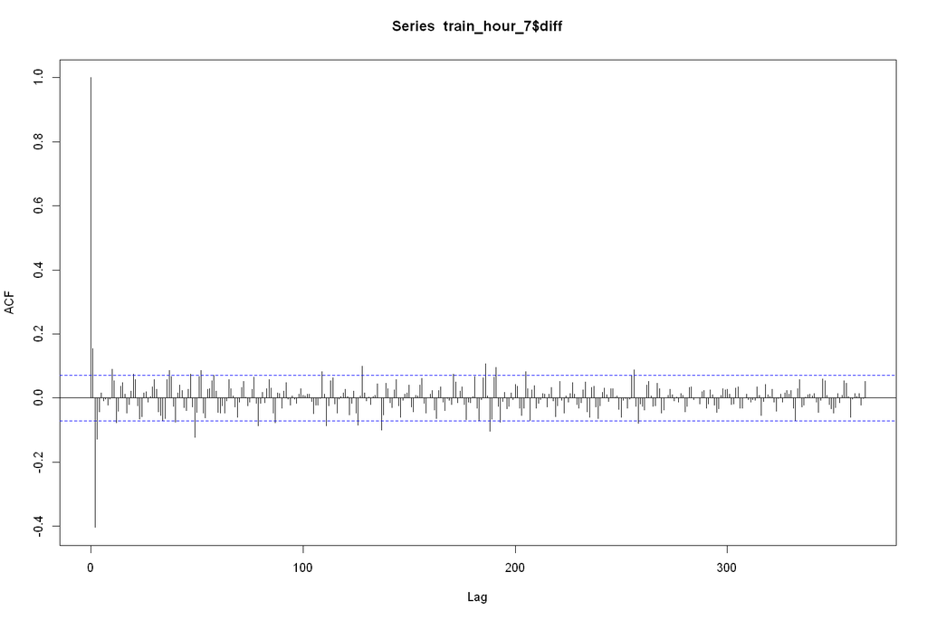

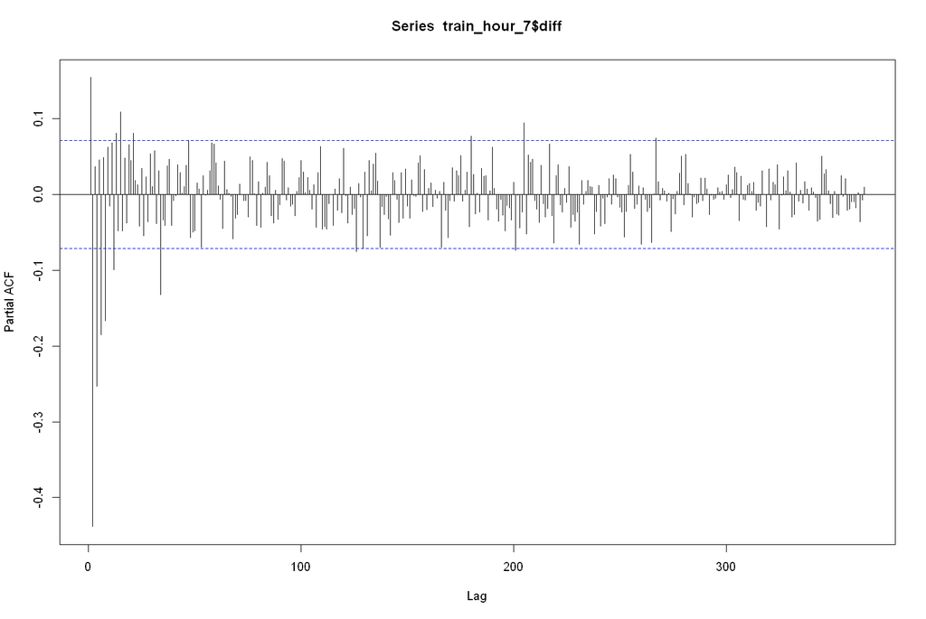

```r
train_hour_7 <- na.omit(train_hour_7)
train_hour_7[,diff:=production - prod_lag_24]

ggplot(train_hour_7,aes(x=date)) + geom_line(aes(y=diff,color='real'))
acf(train_hour_7$diff,lag.max = 365)
pacf(train_hour_7$diff,lag.max = 365)
```

```r
# Fit a simple ARIMA model without external regressors
simple_model <- auto.arima(train_hour_7$diff)
print(summary(simple_model))
```

```
Series: train_hour_7$diff
ARIMA(1,0,2) with zero mean

Coefficients:
         ar1     ma1      ma2
      0.1603  0.1911  -0.7010
s.e.  0.0537  0.0375   0.0318

sigma^2 = 2.386:  log likelihood = -1400.91
AIC=2809.81   AICc=2809.87   BIC=2828.32

Training set error measures:
                     ME     RMSE      MAE MPE MAPE      MASE         ACF1
Training set 0.05620919 1.541624 1.040589 NaN  Inf 0.6586888 -0.006162245
```

```r
predictors <- setdiff(names(train_hour_7), c("date", "hour", "production", "diff"))

# Convert predictors to a numeric matrix
predictor_matrix <- as.matrix(train_hour_7[, ..predictors])

# Perform auto.arima
arima_model_regressors <- auto.arima(train_hour_7$diff, xreg = predictor_matrix)

# Summary of the auto.arima model
summary(arima_model_regressors)
```

```
Error in auto.arima(train_hour_7$diff, xreg = predictor_matrix): No suitable ARIMA model found
Traceback:

1. auto.arima(train_hour_7$diff, xreg = predictor_matrix)
2. stop("No suitable ARIMA model found")
```

Since we have too many variables, auto arima function is not working with such a large regressor matrix.

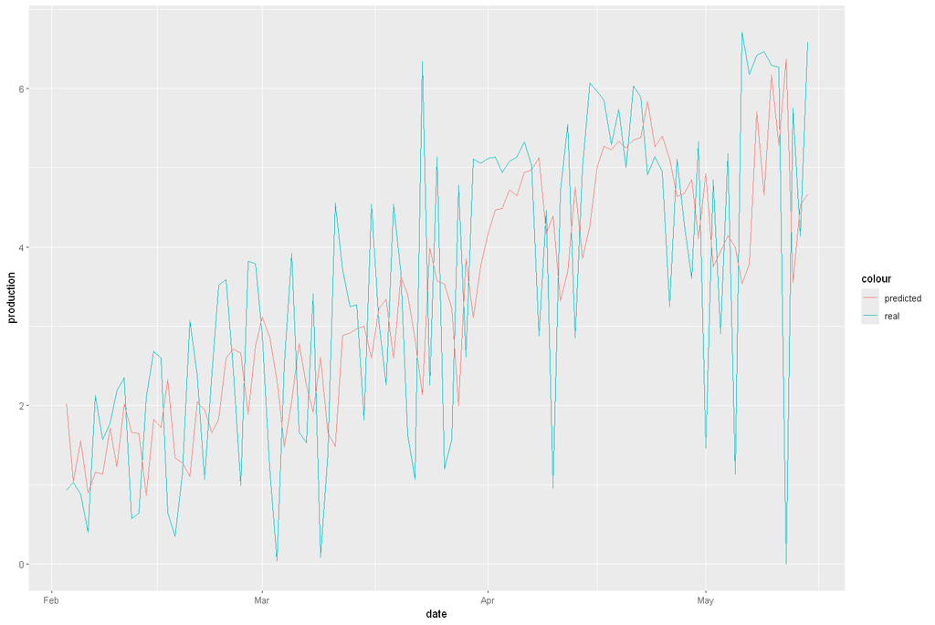

```r
train_model <- Arima(train_hour_7$diff, order = c(1, 0, 2))
test_hour_7[,diff:=production - prod_lag_24]

predictions <- numeric(nrow(test_hour_7))

for (i in 1:nrow(test_hour_7)) {
  # Generate forecast for the next step using the model
  forecast_step <- forecast(train_model, h = 1)

  # Store the forecasted value
  predictions[i] <- forecast_step$mean

  new_data <- c(train_hour_7$diff, test_hour_7$diff[1:i])

  # Refit the model to include the new data
  train_model <- auto.arima(new_data)
}

test_hour_7[,predicted:= prod_lag_24 + predictions]

ggplot(test_hour_7,aes(x=date)) + geom_line(aes(y=production,color='real')) + geom_line(aes(y=predicted,color='predicted'))
```

## Hour 8

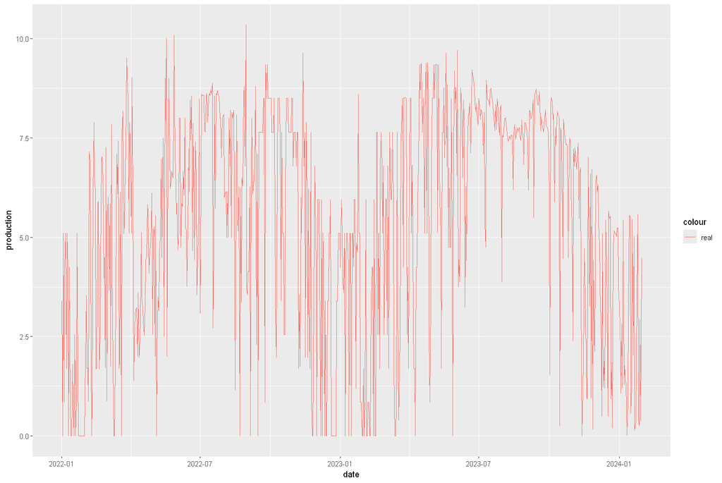

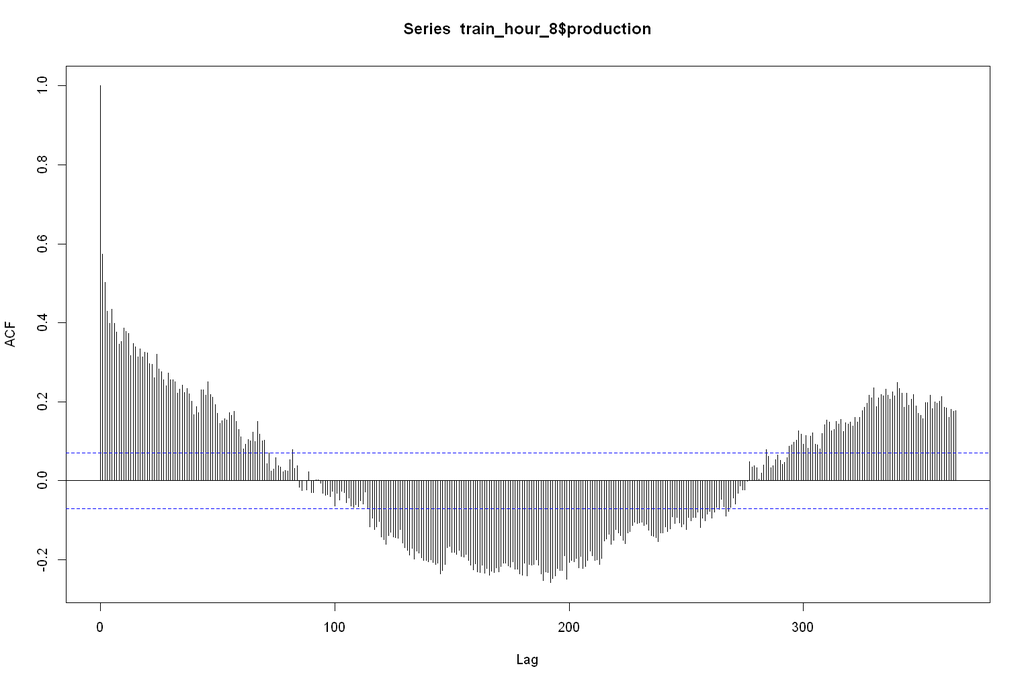

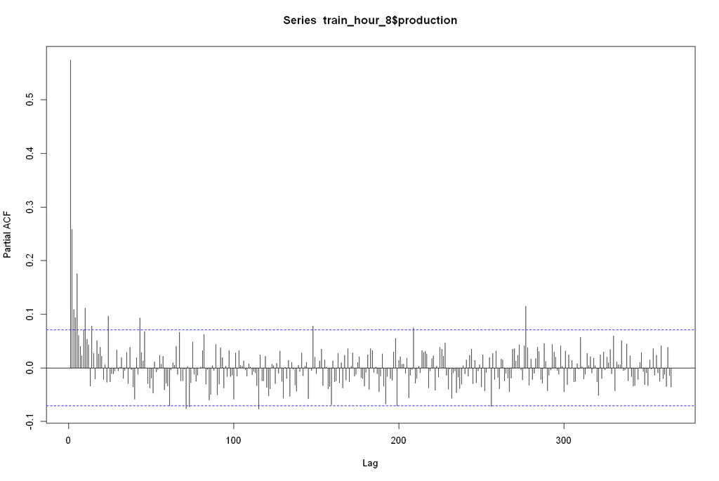

```r
train_hour_8 <- train_split_data_tables[["8"]]
test_hour_8 <- test_split_data_tables[["8"]]

ggplot(train_hour_8,aes(x=date)) + geom_line(aes(y=production,color='real'))
acf(train_hour_8$production,lag.max = 365)
pacf(train_hour_8$production,lag.max = 365)
```

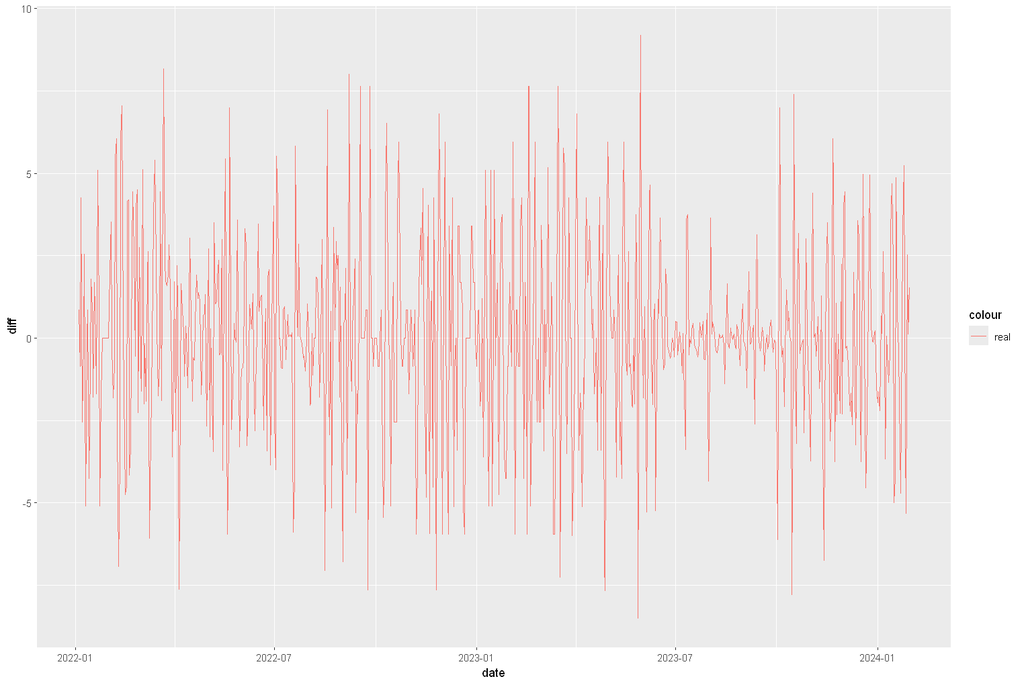

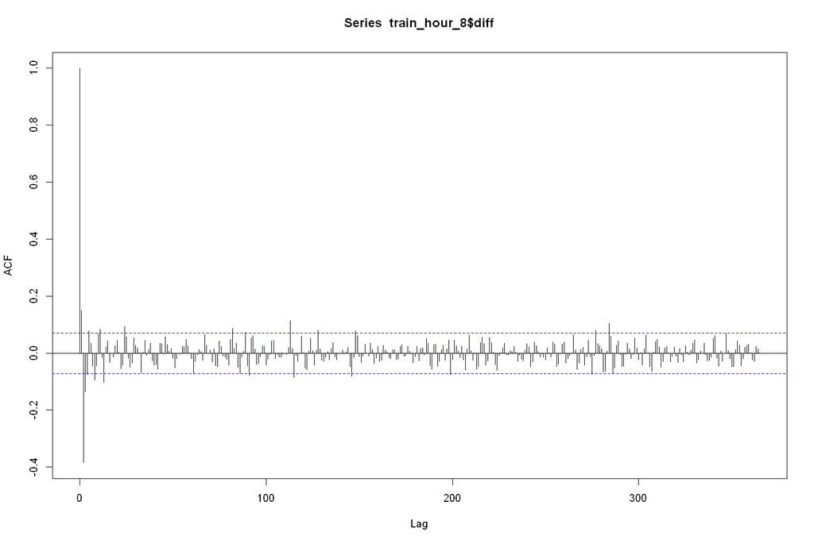

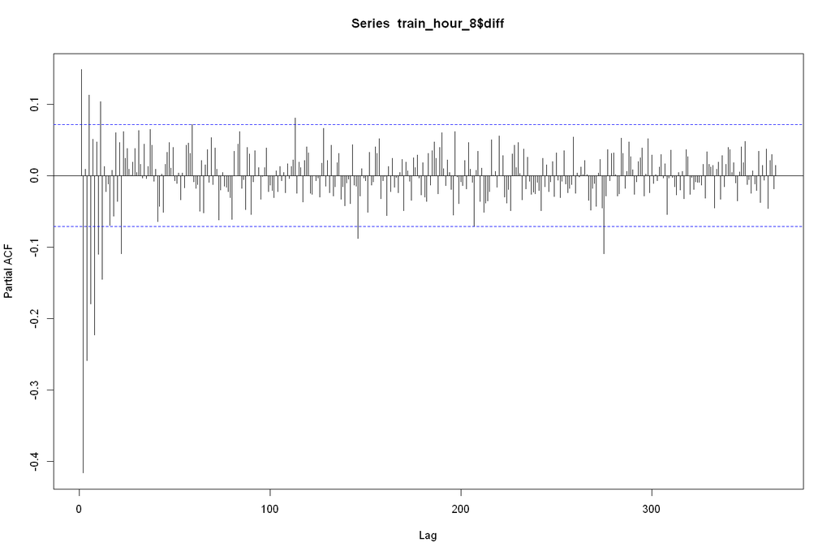

```r
train_hour_8 <- na.omit(train_hour_8)
train_hour_8[,diff:=production - prod_lag_24]

ggplot(train_hour_8,aes(x=date)) + geom_line(aes(y=diff,color='real'))
acf(train_hour_8$diff,lag.max = 365)
pacf(train_hour_8$diff,lag.max = 365)
```

```r
# Fit a simple ARIMA model without external regressors
simple_model <- auto.arima(train_hour_8$diff)
print(summary(simple_model))
```

```
Series: train_hour_8$diff
ARIMA(0,0,1) with non-zero mean

Coefficients:
         ma1    mean
      0.9512  0.0530
s.e.  0.0209  0.1842

sigma^2 = 6.776:  log likelihood = -1798.55
AIC=3603.1   AICc=3603.13   BIC=3616.99

Training set error measures:
                       ME     RMSE      MAE MPE MAPE      MASE       ACF1
Training set -0.003066558 2.599714 1.857628 NaN  Inf 0.6910915 -0.3910016
```

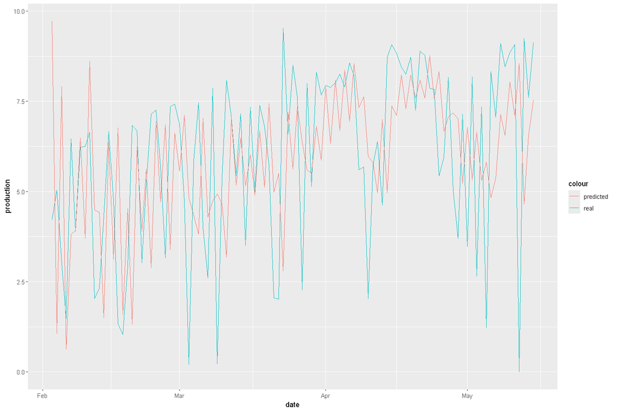

```r
train_model <- Arima(train_hour_8$diff, order = c(0, 0, 1))
test_hour_8[,diff:=production - prod_lag_24]

predictions <- numeric(nrow(test_hour_8))

for (i in 1:nrow(test_hour_8)) {
  # Generate forecast for the next step using the model
  forecast_step <- forecast(train_model, h = 1)

  # Store the forecasted value
  predictions[i] <- forecast_step$mean

  new_data <- c(train_hour_8$diff, test_hour_8$diff[1:i])

  # Refit the model to include the new data
  train_model <- auto.arima(new_data)
}

test_hour_8[,predicted:= prod_lag_24 + predictions]

ggplot(test_hour_8,aes(x=date)) + geom_line(aes(y=production,color='real')) + geom_line(aes(y=predicted,color='predicted'))
```

## Hour 9

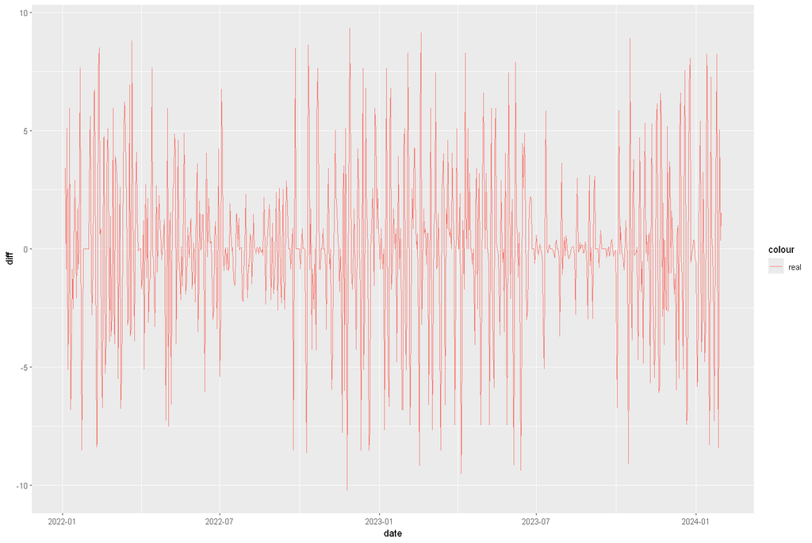

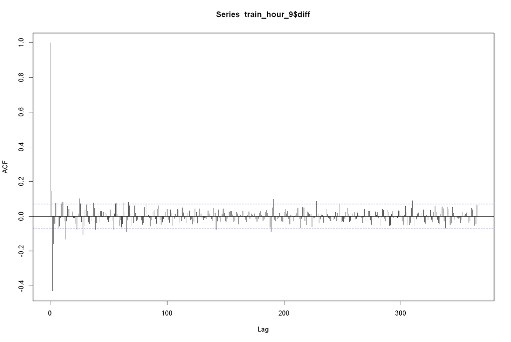

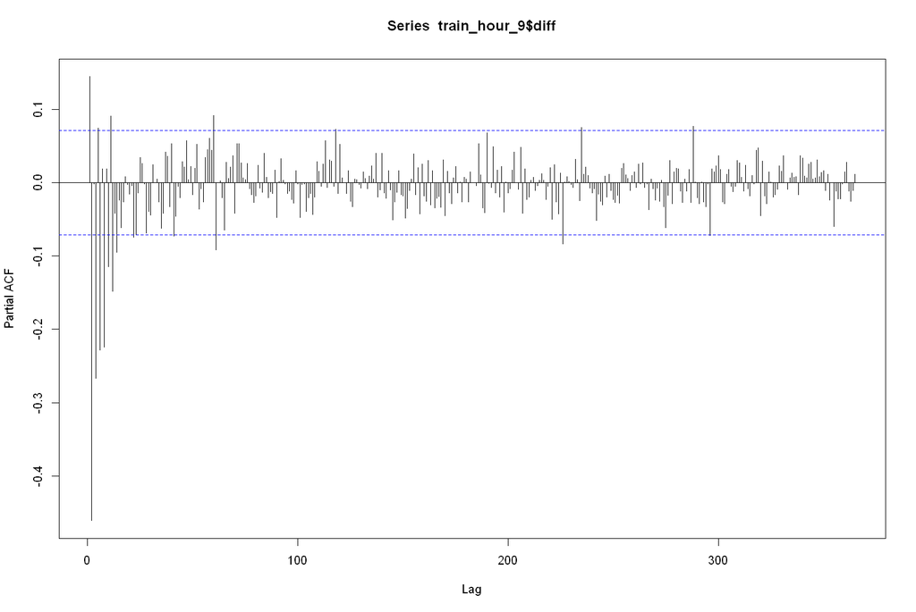

```r
train_hour_9 <- train_split_data_tables[["9"]]
test_hour_9 <- test_split_data_tables[["9"]]

train_hour_9 <- na.omit(train_hour_9)
train_hour_9[,diff:=production - prod_lag_24]

ggplot(train_hour_9,aes(x=date)) + geom_line(aes(y=diff,color='real'))
acf(train_hour_9$diff,lag.max = 365)
pacf(train_hour_9$diff,lag.max = 365)
```

```r
# Fit a simple ARIMA model without external regressors
simple_model <- auto.arima(train_hour_9$diff)
print(summary(simple_model))
```

```
Series: train_hour_9$diff
ARIMA(5,0,5) with zero mean

Coefficients:
         ar1      ar2      ar3     ar4     ar5     ma1      ma2     ma3
      0.0888  -0.1595  -0.4161  0.1164  0.1286  0.2109  -0.6104  0.3533
s.e.  0.1806   0.2234   0.1973  0.0777  0.0432  0.1774   0.2460  0.2279
          ma4      ma5
      -0.1982  -0.4698
s.e.   0.2007   0.1961

sigma^2 = 6.849:  log likelihood = -1798.68
AIC=3619.37   AICc=3619.72   BIC=3670.29

Training set error measures:
                     ME     RMSE      MAE MPE MAPE      MASE        ACF1
Training set 0.05638456 2.599707 1.956106 NaN  Inf 0.6183894 0.002009763
```

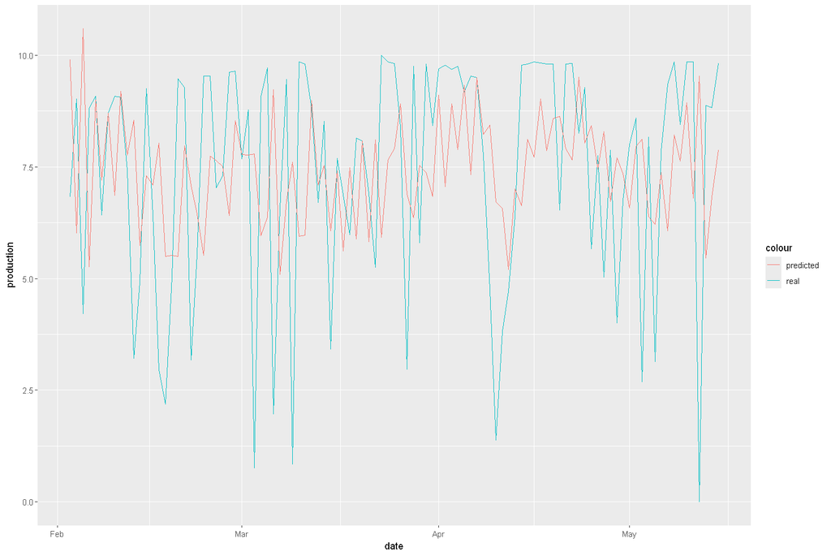

```r
train_model <- Arima(train_hour_9$diff, order = c(5, 0, 5))
test_hour_9[,diff:=production - prod_lag_24]

predictions <- numeric(nrow(test_hour_9))

for (i in 1:nrow(test_hour_9)) {
  # Generate forecast for the next step using the model
  forecast_step <- forecast(train_model, h = 1)

  # Store the forecasted value
  predictions[i] <- forecast_step$mean

  new_data <- c(train_hour_9$diff, test_hour_9$diff[1:i])

  # Refit the model to include the new data
  train_model <- auto.arima(new_data)
}

test_hour_9[,predicted:= prod_lag_24 + predictions]

ggplot(test_hour_9,aes(x=date)) + geom_line(aes(y=production,color='real')) + geom_line(aes(y=predicted,color='predicted'))
```

## Hour 10

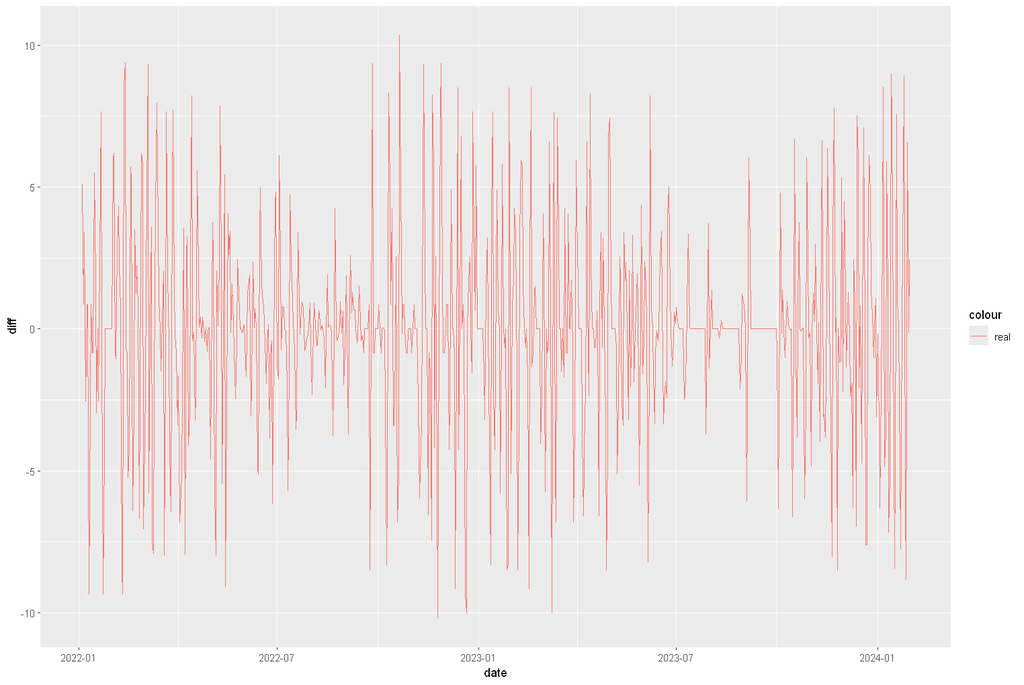

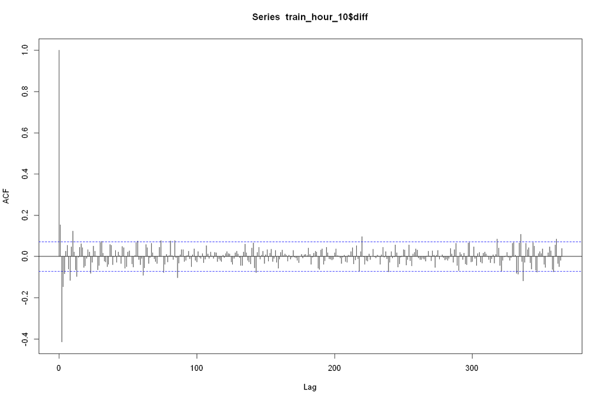

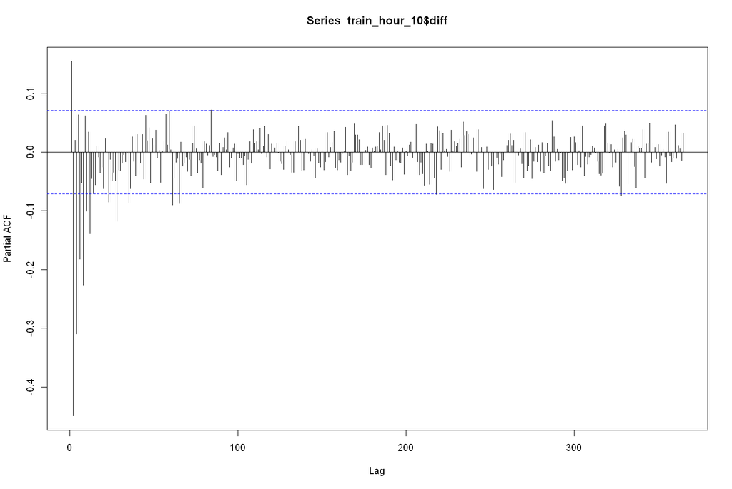

```r
train_hour_10 <- train_split_data_tables[["10"]]
test_hour_10 <- test_split_data_tables[["10"]]

train_hour_10 <- na.omit(train_hour_10)
train_hour_10[,diff:=production - prod_lag_24]

ggplot(train_hour_10,aes(x=date)) + geom_line(aes(y=diff,color='real'))
acf(train_hour_10$diff,lag.max = 365)
pacf(train_hour_10$diff,lag.max = 365)
```

```r
# Fit a simple ARIMA model without external regressors
simple_model <- auto.arima(train_hour_10$diff)
print(summary(simple_model))
```

```
Series: train_hour_10$diff
ARIMA(2,0,3) with zero mean

Coefficients:
         ar1      ar2      ma1      ma2     ma3
      0.9751  -0.1780  -0.6990  -0.8372  0.5612
s.e.  0.5795   0.2235   0.5736   0.0468  0.4896

sigma^2 = 7.737:  log likelihood = -1844.93
AIC=3701.87   AICc=3701.98   BIC=3729.64

Training set error measures:
                      ME     RMSE      MAE MPE MAPE      MASE         ACF1
Training set -0.03008695 2.772274 2.030623 NaN  Inf 0.6340396 -0.005686498
```

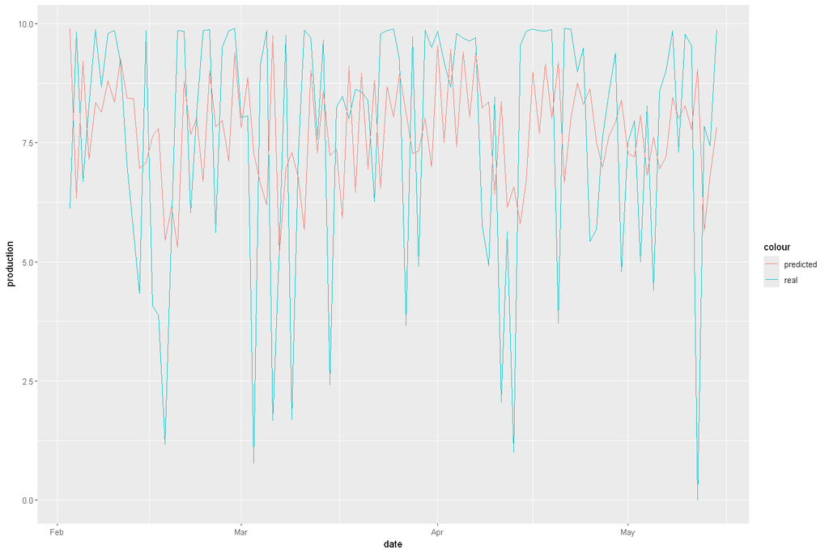

```r
train_model <- Arima(train_hour_10$diff, order = c(2, 0, 3))
test_hour_10[,diff:=production - prod_lag_24]

predictions <- numeric(nrow(test_hour_10))

for (i in 1:nrow(test_hour_10)) {
  # Generate forecast for the next step using the model
  forecast_step <- forecast(train_model, h = 1)

  # Store the forecasted value
  predictions[i] <- forecast_step$mean

  new_data <- c(train_hour_10$diff, test_hour_10$diff[1:i])

  # Refit the model to include the new data
  train_model <- auto.arima(new_data)
}

test_hour_10[,predicted:= prod_lag_24 + predictions]

ggplot(test_hour_10,aes(x=date)) + geom_line(aes(y=production,color='real')) + geom_line(aes(y=predicted,color='predicted'))
```

## Hour 11

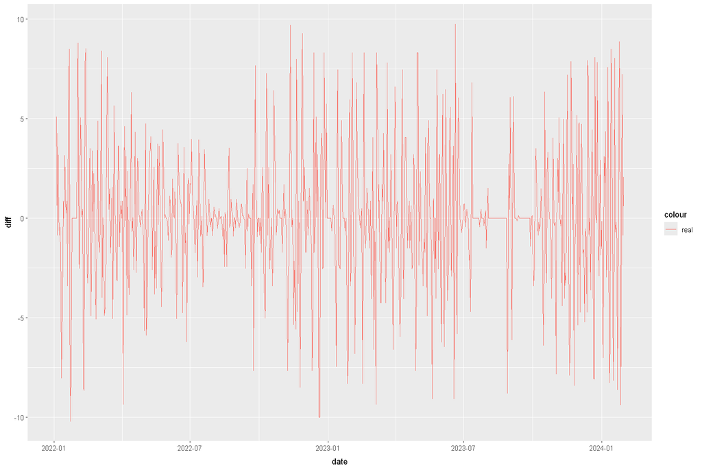

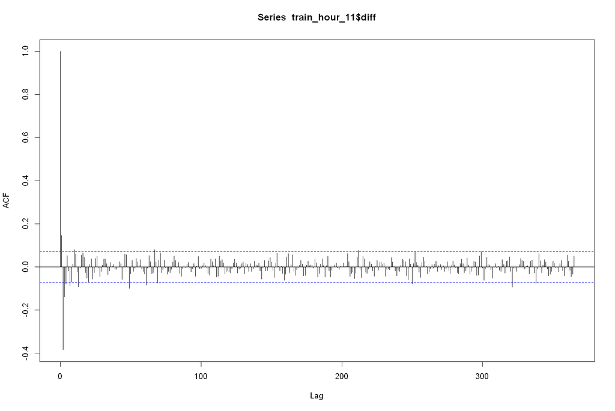

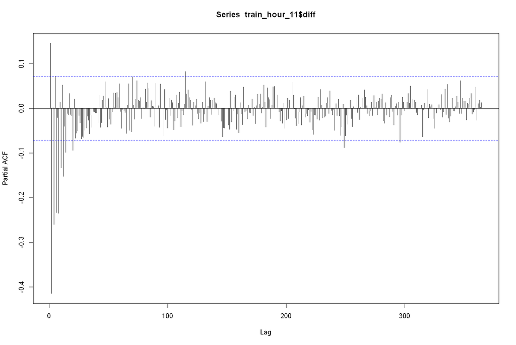

```r
train_hour_11 <- train_split_data_tables[["11"]]
test_hour_11 <- test_split_data_tables[["11"]]

train_hour_11 <- na.omit(train_hour_11)
train_hour_11[,diff:=production - prod_lag_24]

ggplot(train_hour_11,aes(x=date)) + geom_line(aes(y=diff,color='real'))
acf(train_hour_11$diff,lag.max = 365)
pacf(train_hour_11$diff,lag.max = 365)
```

```r
# Fit a simple ARIMA model without external regressors
simple_model <- auto.arima(train_hour_11$diff)
print(summary(simple_model))
```

```
Series: train_hour_11$diff
ARIMA(2,0,2) with zero mean

Coefficients:
         ar1     ar2     ma1      ma2
      0.2664  0.1145  0.0213  -0.9333
s.e.  0.0400  0.0399  0.0161   0.0161

sigma^2 = 7.116:  log likelihood = -1816.74
AIC=3643.48   AICc=3643.56   BIC=3666.63

Training set error measures:
                     ME     RMSE      MAE MPE MAPE      MASE         ACF1
Training set 0.02969734 2.660538 1.995048 NaN  Inf 0.6397529 -0.002865568
```

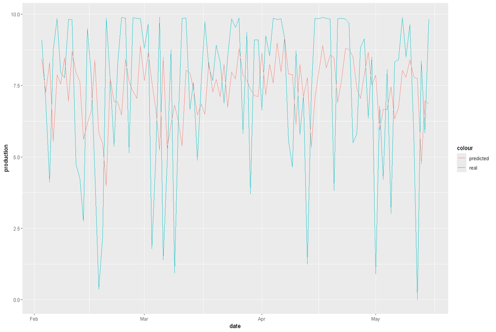

```r
train_model <- Arima(train_hour_11$diff, order = c(2, 0, 2))
test_hour_11[,diff:=production - prod_lag_24]

predictions <- numeric(nrow(test_hour_11))

for (i in 1:nrow(test_hour_11)) {
  # Generate forecast for the next step using the model
  forecast_step <- forecast(train_model, h = 1)

  # Store the forecasted value
  predictions[i] <- forecast_step$mean

  new_data <- c(train_hour_11$diff, test_hour_11$diff[1:i])

  # Refit the model to include the new data
  train_model <- auto.arima(new_data)
}

test_hour_11[,predicted:= prod_lag_24 + predictions]

ggplot(test_hour_11,aes(x=date)) + geom_line(aes(y=production,color='real')) + geom_line(aes(y=predicted,color='predicted'))
```

## Hour 12

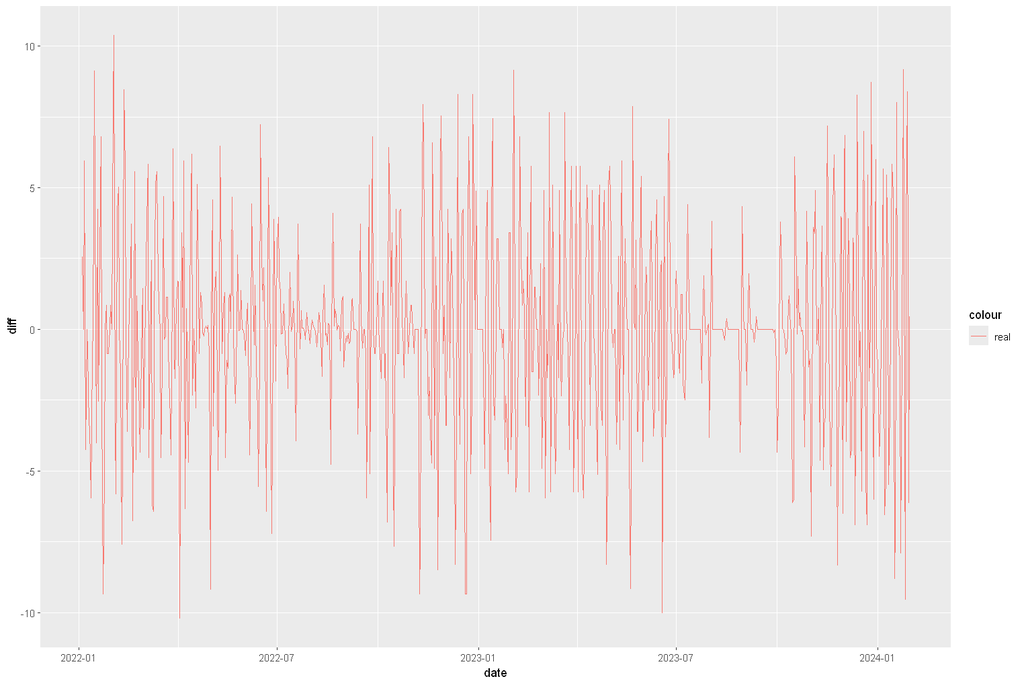

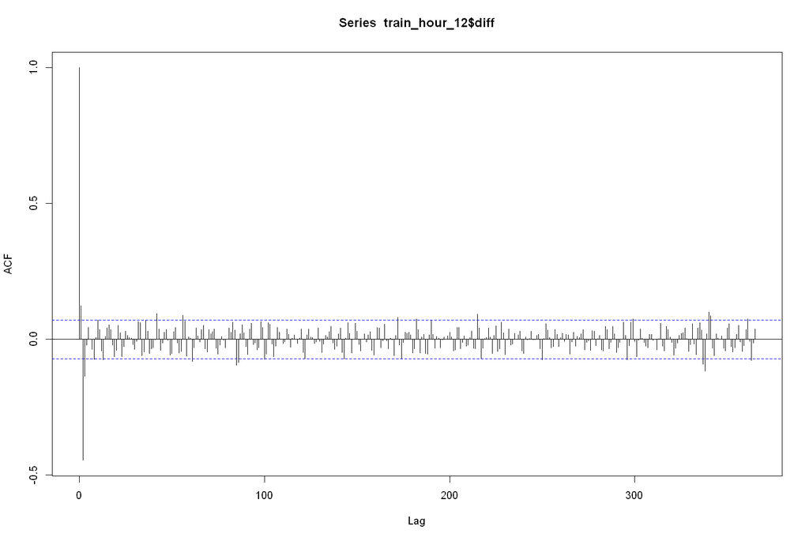

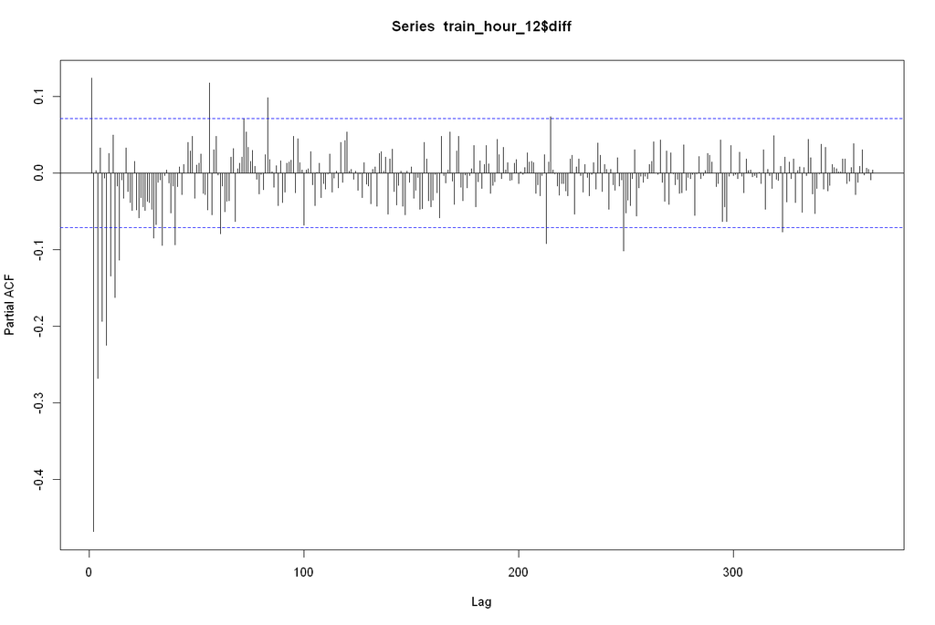

```r
train_hour_12 <- train_split_data_tables[["12"]]
test_hour_12 <- test_split_data_tables[["12"]]

train_hour_12 <- na.omit(train_hour_12)
train_hour_12[,diff:=production - prod_lag_24]

ggplot(train_hour_12,aes(x=date)) + geom_line(aes(y=diff,color='real'))
acf(train_hour_12$diff,lag.max = 365)
pacf(train_hour_12$diff,lag.max = 365)
```

```r
# Fit a simple ARIMA model without external regressors
simple_model <- auto.arima(train_hour_12$diff)
print(summary(simple_model))
```

```
Series: train_hour_12$diff
ARIMA(4,0,3) with zero mean

Coefficients:
         ar1      ar2      ar3     ar4      ma1      ma2     ma3
      0.6061  -0.0173  -0.0366  0.0357  -0.3695  -0.9137  0.3337
s.e.  0.5092   0.1324   0.0575  0.0406   0.5089   0.0210  0.4621

sigma^2 = 6.948:  log likelihood = -1803.53
AIC=3623.05   AICc=3623.25   BIC=3660.08

Training set error measures:
                      ME     RMSE      MAE MPE MAPE     MASE        ACF1
Training set -0.04207267 2.623652 2.004132 NaN  Inf 0.612852 -0.00525723
```

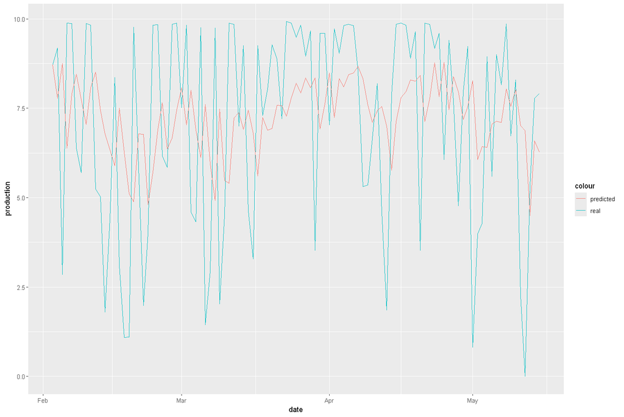

```r
train_model <- Arima(train_hour_12$diff, order = c(4, 0, 3))
test_hour_12[,diff:=production - prod_lag_24]

predictions <- numeric(nrow(test_hour_12))

for (i in 1:nrow(test_hour_12)) {
  # Generate forecast for the next step using the model
  forecast_step <- forecast(train_model, h = 1)

  # Store the forecasted value
  predictions[i] <- forecast_step$mean

  new_data <- c(train_hour_12$diff, test_hour_12$diff[1:i])

  # Refit the model to include the new data
  train_model <- auto.arima(new_data)
}

test_hour_12[,predicted:= prod_lag_24 + predictions]

ggplot(test_hour_12,aes(x=date)) + geom_line(aes(y=production,color='real')) + geom_line(aes(y=predicted,color='predicted'))
```

## Hour 13

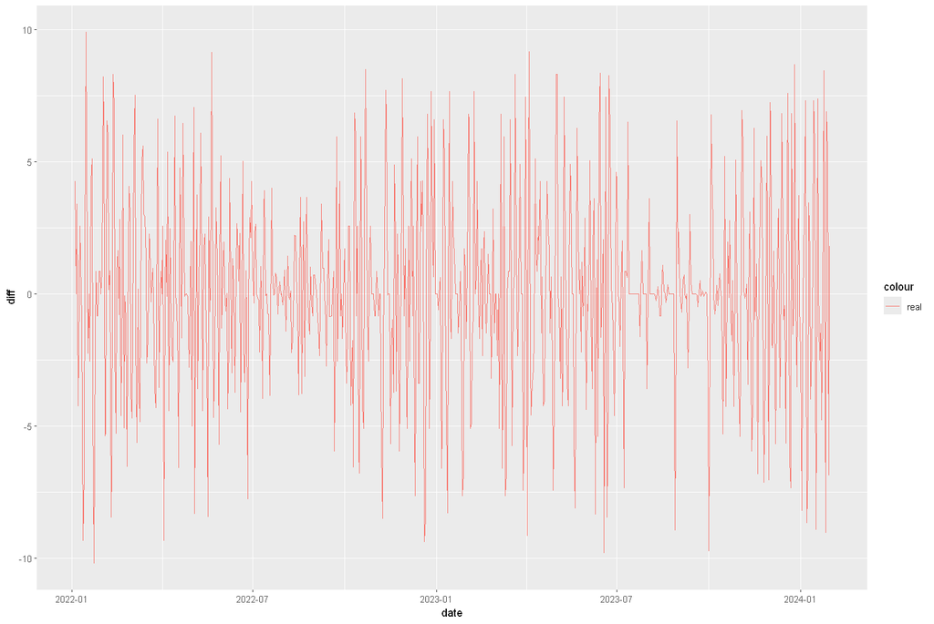

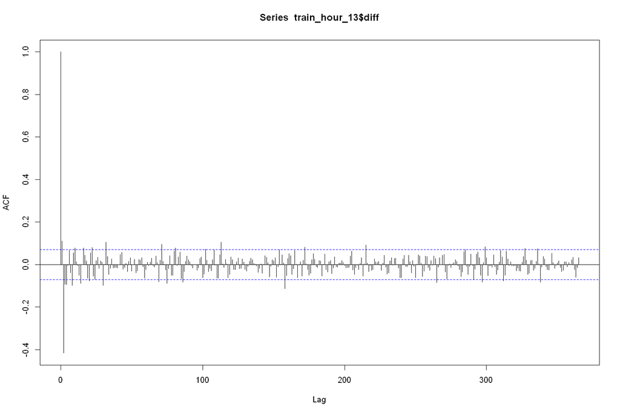

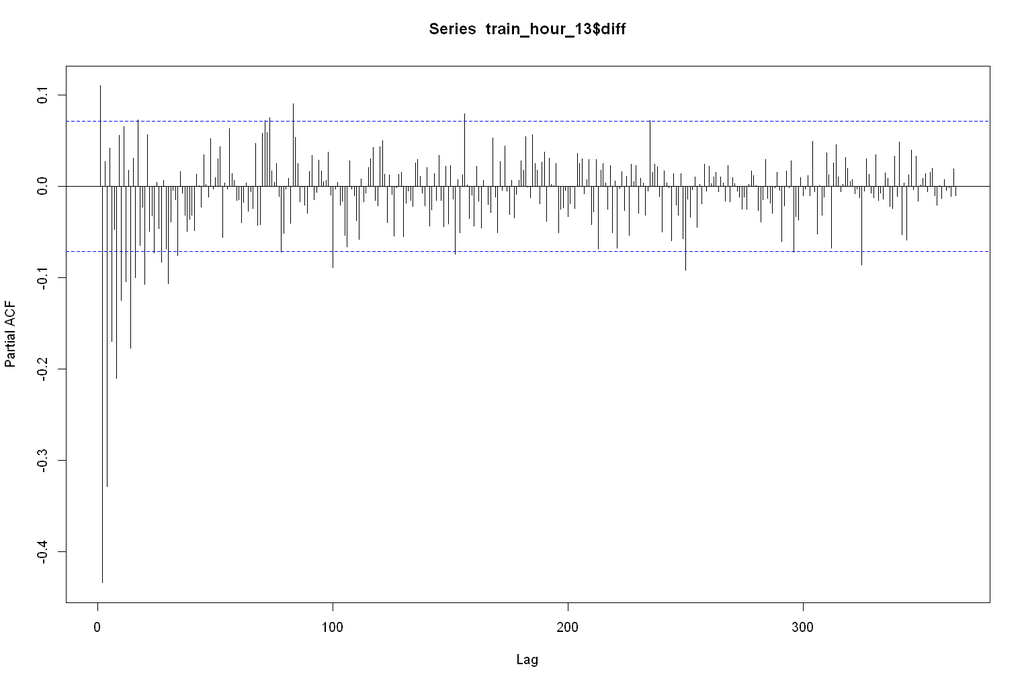

```r
train_hour_13 <- train_split_data_tables[["13"]]
test_hour_13 <- test_split_data_tables[["13"]]

train_hour_13 <- na.omit(train_hour_13)
train_hour_13[,diff:=production - prod_lag_24]

ggplot(train_hour_13,aes(x=date)) + geom_line(aes(y=diff,color='real'))
acf(train_hour_13$diff,lag.max = 365)
pacf(train_hour_13$diff,lag.max = 365)
```

```r
# Fit a simple ARIMA model without external regressors
simple_model <- auto.arima(train_hour_13$diff)
print(summary(simple_model))
```

```
Series: train_hour_13$diff
ARIMA(0,0,1) with non-zero mean

Coefficients:
         ma1    mean
      0.9855  0.0129
s.e.  0.0116  0.2454

sigma^2 = 11.61:  log likelihood = -2003.01
AIC=4012.01   AICc=4012.05   BIC=4025.9

Training set error measures:
                       ME     RMSE      MAE MPE MAPE      MASE       ACF1
Training set -0.005189826 3.403133 2.405518 NaN  Inf 0.6687672 -0.4200273
```

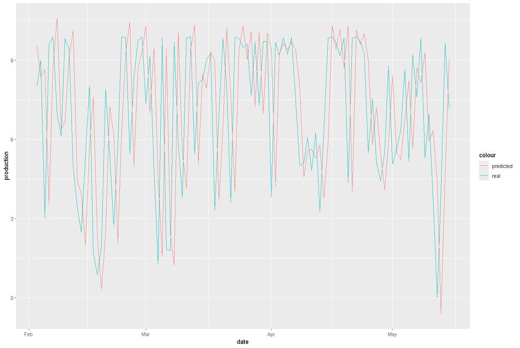

```r
train_model <- Arima(train_hour_13$diff, order = c(0, 0, 1))
test_hour_13[,diff:=production - prod_lag_24]

predictions <- numeric(nrow(test_hour_13))

for (i in 1:nrow(test_hour_13)) {
  # Generate forecast for the next step using the model
  forecast_step <- forecast(train_model, h = 1)

  # Store the forecasted value
  predictions[i] <- forecast_step$mean

  new_data <- c(train_hour_13$diff, test_hour_13$diff[1:i])

  # Refit the model to include the new data
  train_model <- auto.arima(new_data)
}

test_hour_13[,predicted:= prod_lag_24 + predictions]

ggplot(test_hour_13,aes(x=date)) + geom_line(aes(y=production,color='real')) + geom_line(aes(y=predicted,color='predicted'))
```

## Hour 14

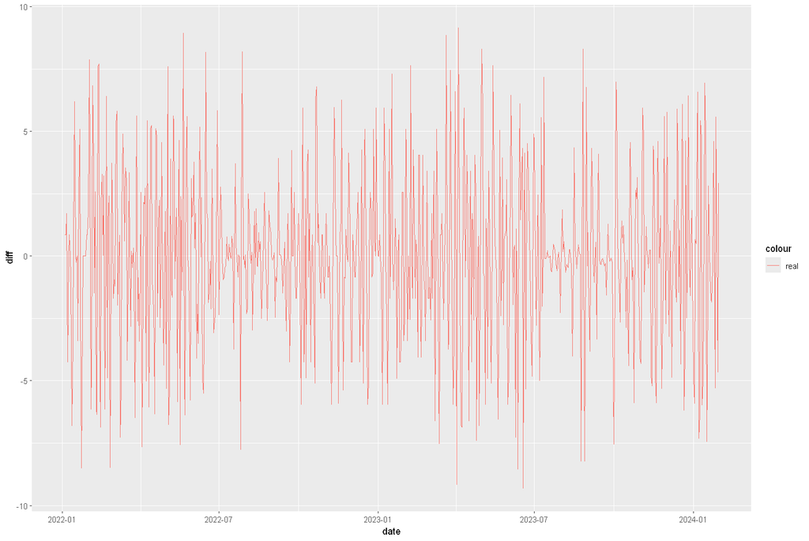

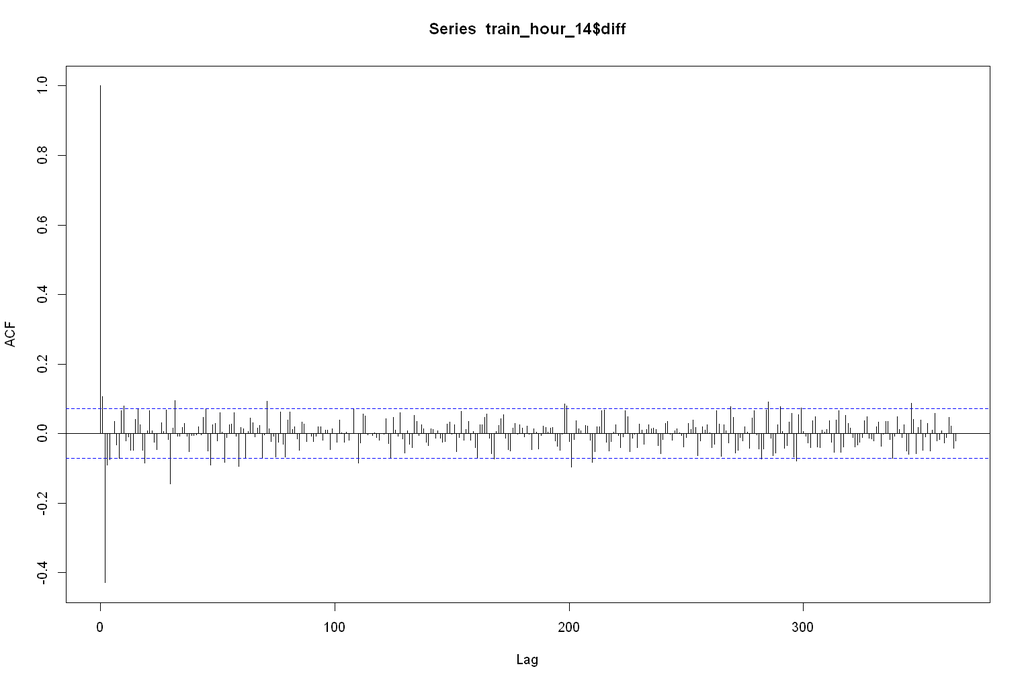

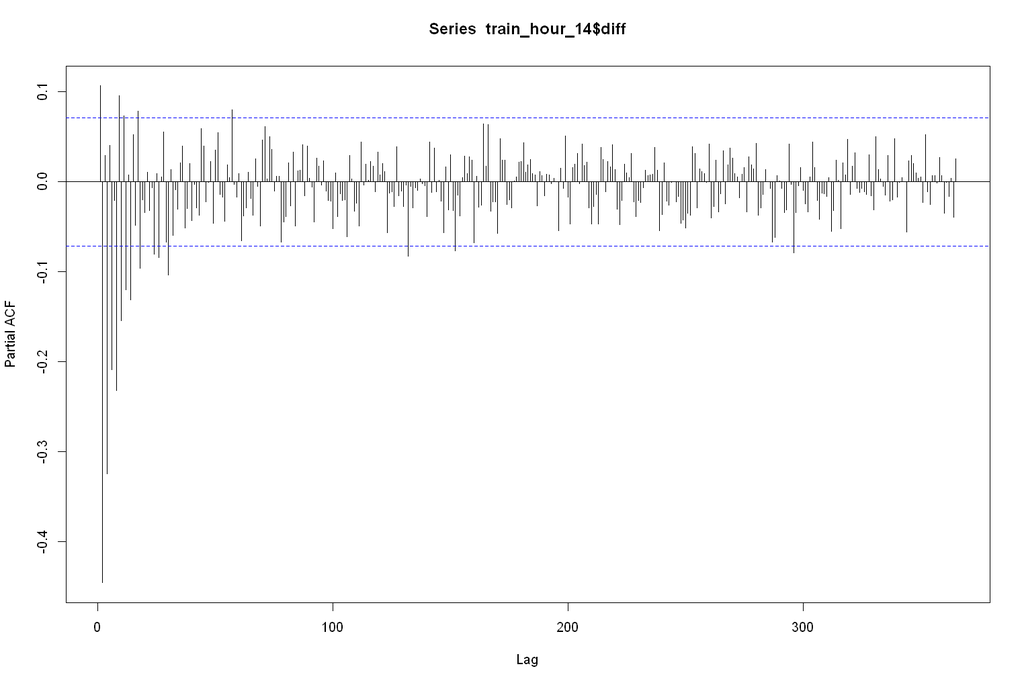

```r
train_hour_14 <- train_split_data_tables[["14"]]
test_hour_14 <- test_split_data_tables[["14"]]

train_hour_14 <- na.omit(train_hour_14)
train_hour_14[,diff:=production - prod_lag_24]

ggplot(train_hour_14,aes(x=date)) + geom_line(aes(y=diff,color='real'))
acf(train_hour_14$diff,lag.max = 365)
pacf(train_hour_14$diff,lag.max = 365)
```

```r
# Fit a simple ARIMA model without external regressors
simple_model <- auto.arima(train_hour_14$diff)
print(summary(simple_model))
```

```
Series: train_hour_14$diff
ARIMA(1,0,2) with zero mean

Coefficients:
         ar1     ma1      ma2
      0.2213  0.0502  -0.8629
s.e.  0.0448  0.0249   0.0221

sigma^2 = 6.742:  log likelihood = -1796.37
AIC=3600.75   AICc=3600.8   BIC=3619.26

Training set error measures:
                     ME     RMSE      MAE MPE MAPE      MASE         ACF1
Training set -0.0745375 2.591372 2.067182 NaN  Inf 0.6065033 -0.009112318
```

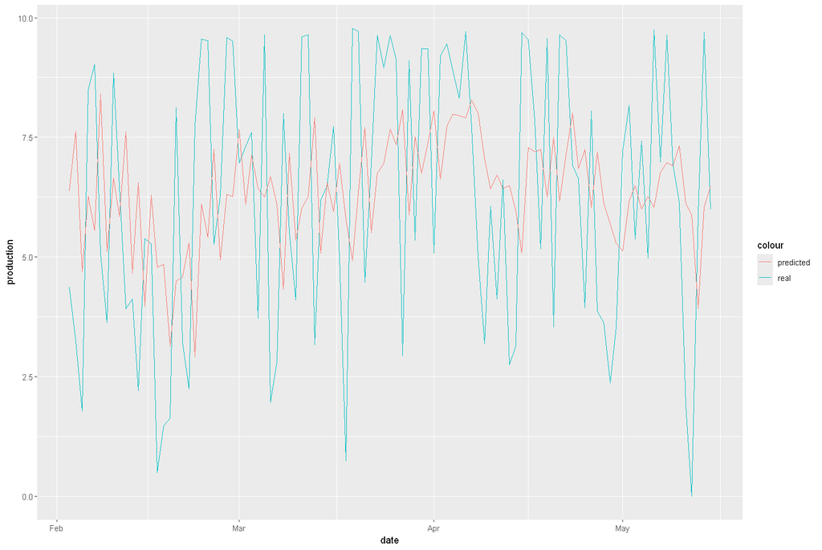

```r
train_model <- Arima(train_hour_14$diff, order = c(1, 0, 2))
test_hour_14[,diff:=production - prod_lag_24]

predictions <- numeric(nrow(test_hour_14))

for (i in 1:nrow(test_hour_14)) {
  # Generate forecast for the next step using the model
  forecast_step <- forecast(train_model, h = 1)

  # Store the forecasted value
  predictions[i] <- forecast_step$mean

  new_data <- c(train_hour_14$diff, test_hour_14$diff[1:i])

  # Refit the model to include the new data
  train_model <- auto.arima(new_data)
}

test_hour_14[,predicted:= prod_lag_24 + predictions]

ggplot(test_hour_14,aes(x=date)) + geom_line(aes(y=production,color='real')) + geom_line(aes(y=predicted,color='predicted'))
```

## Hour 15

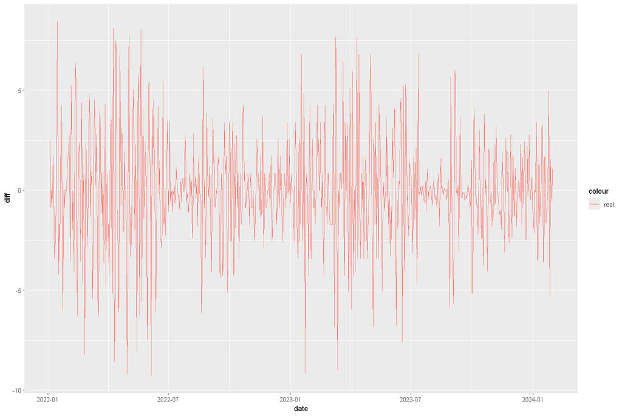

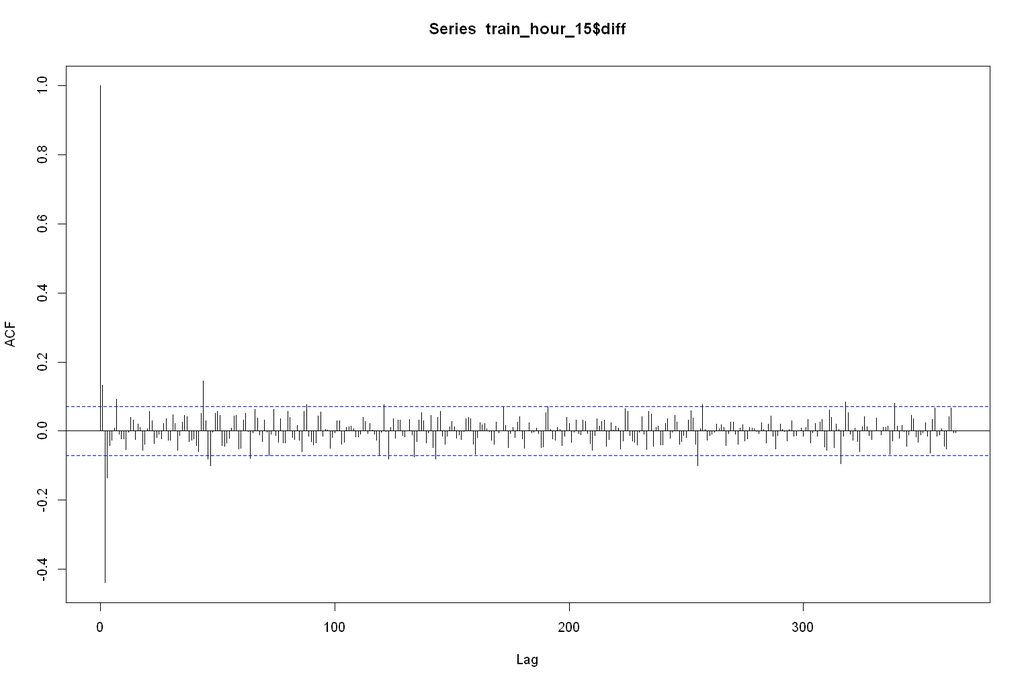

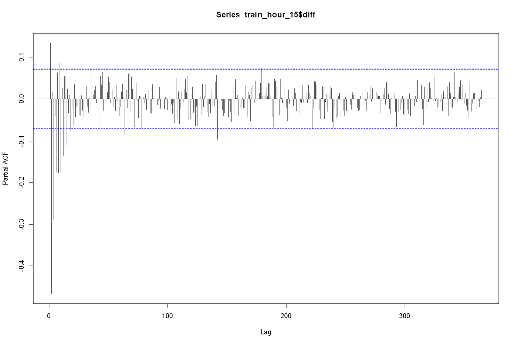

```r
train_hour_15 <- train_split_data_tables[["15"]]
test_hour_15 <- test_split_data_tables[["15"]]

train_hour_15 <- na.omit(train_hour_15)
train_hour_15[,diff:=production - prod_lag_24]

ggplot(train_hour_15,aes(x=date)) + geom_line(aes(y=diff,color='real'))
acf(train_hour_15$diff,lag.max = 365)
pacf(train_hour_15$diff,lag.max = 365)
```

```r
# Fit a simple ARIMA model without external regressors
simple_model <- auto.arima(train_hour_15$diff)
print(summary(simple_model))
```

```
Series: train_hour_15$diff
ARIMA(1,0,2) with zero mean

Coefficients:
         ar1     ma1      ma2
      0.2188  0.0507  -0.8181
s.e.  0.0468  0.0289   0.0238

sigma^2 = 4.545:  log likelihood = -1644.68
AIC=3297.35   AICc=3297.41   BIC=3315.87

Training set error measures:
                      ME     RMSE      MAE MPE MAPE      MASE         ACF1
Training set -0.08556927 2.127715 1.614939 NaN  Inf 0.6319405 -0.009880985
```

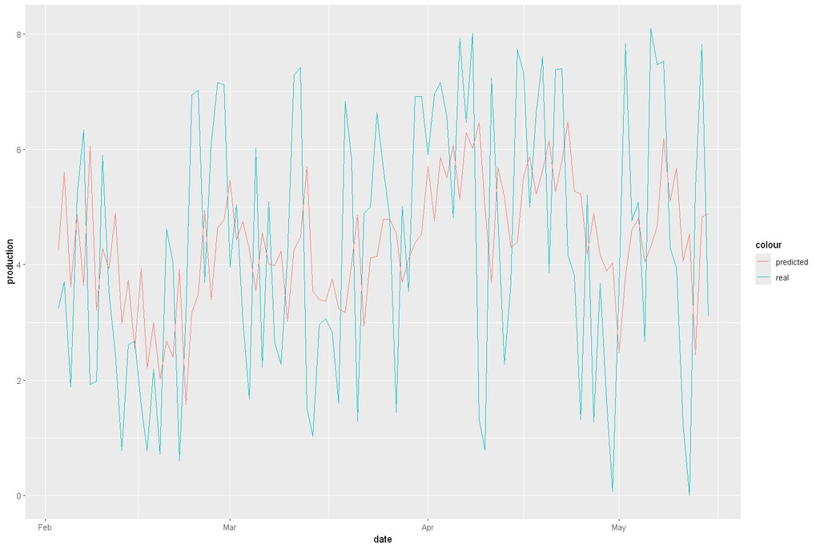

```r
train_model <- Arima(train_hour_15$diff, order = c(1, 0, 2))
test_hour_15[,diff:=production - prod_lag_24]

predictions <- numeric(nrow(test_hour_15))

for (i in 1:nrow(test_hour_15)) {
  # Generate forecast for the next step using the model
  forecast_step <- forecast(train_model, h = 1)

  # Store the forecasted value
  predictions[i] <- forecast_step$mean

  new_data <- c(train_hour_15$diff, test_hour_15$diff[1:i])

  # Refit the model to include the new data
  train_model <- auto.arima(new_data)
}

test_hour_15[,predicted:= prod_lag_24 + predictions]

ggplot(test_hour_15,aes(x=date)) + geom_line(aes(y=production,color='real')) + geom_line(aes(y=predicted,color='predicted'))
```

## Hour 16

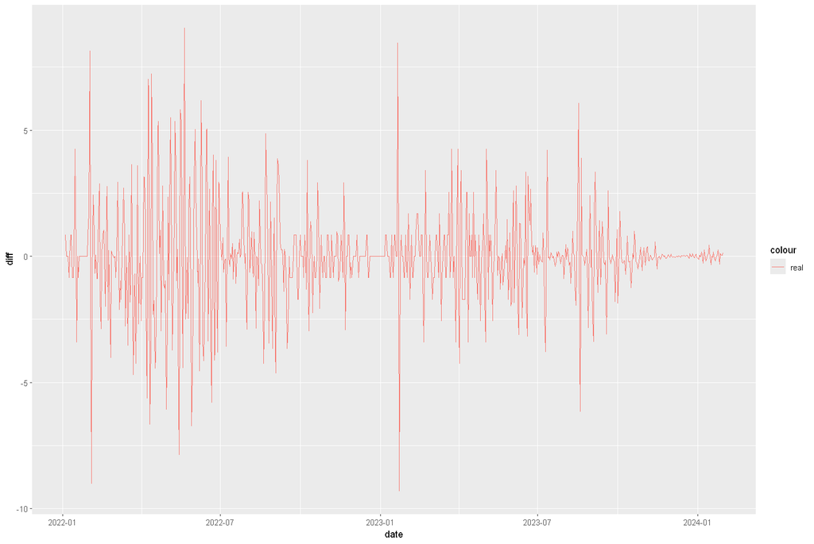

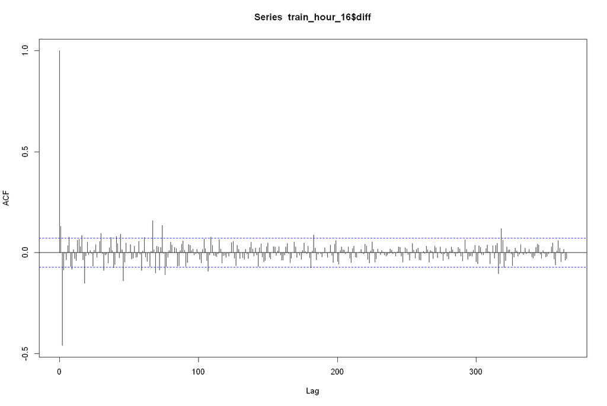

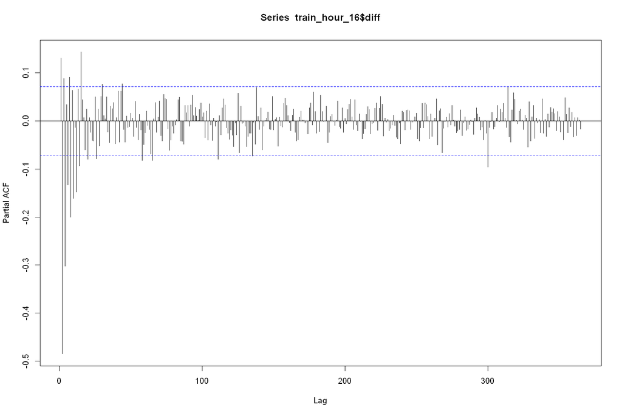

```r
train_hour_16 <- train_split_data_tables[["16"]]
test_hour_16 <- test_split_data_tables[["16"]]

train_hour_16 <- na.omit(train_hour_16)
train_hour_16[,diff:=production - prod_lag_24]

ggplot(train_hour_16,aes(x=date)) + geom_line(aes(y=diff,color='real'))
acf(train_hour_16$diff,lag.max = 365)
pacf(train_hour_16$diff,lag.max = 365)
```

```r
# Fit a simple ARIMA model without external regressors
simple_model <- auto.arima(train_hour_16$diff)
print(summary(simple_model))
```

```
Series: train_hour_16$diff
ARIMA(0,0,3) with zero mean

Coefficients:
         ma1      ma2      ma3
      0.3671  -0.7206  -0.1706
s.e.  0.0358   0.0288   0.0359

sigma^2 = 2.281:  log likelihood = -1385.81
AIC=2779.62   AICc=2779.67   BIC=2798.14

Training set error measures:
                      ME     RMSE      MAE MPE MAPE      MASE         ACF1
Training set -0.06479397 1.507167 0.971088 NaN  Inf 0.6124438 -0.000201934
```

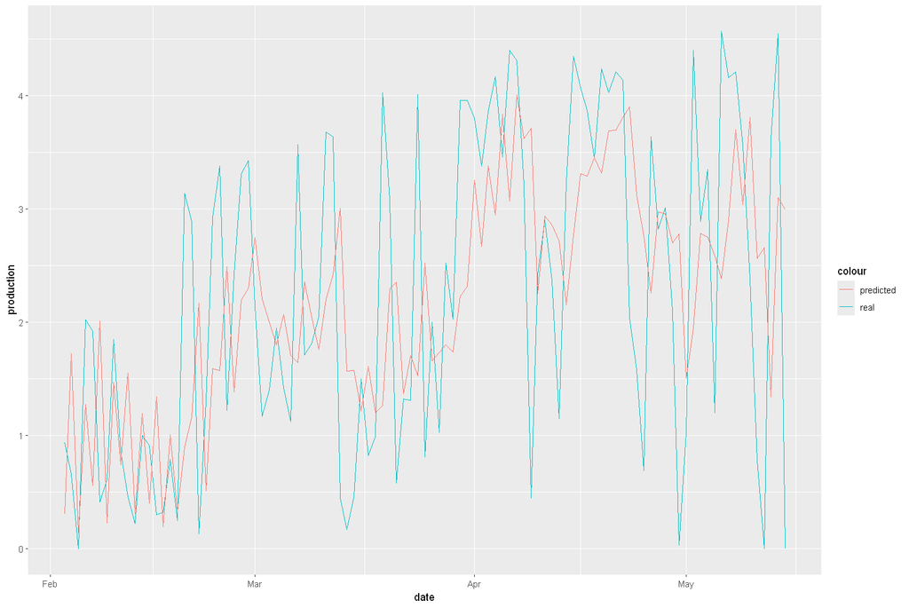

```r
train_model <- Arima(train_hour_16$diff, order = c(1, 0, 2))
test_hour_16[,diff:=production - prod_lag_24]

predictions <- numeric(nrow(test_hour_16))

for (i in 1:nrow(test_hour_16)) {
  # Generate forecast for the next step using the model
  forecast_step <- forecast(train_model, h = 1)

  # Store the forecasted value
  predictions[i] <- forecast_step$mean

  new_data <- c(train_hour_16$diff, test_hour_16$diff[1:i])

  # Refit the model to include the new data
  train_model <- auto.arima(new_data)
}

test_hour_16[,predicted:= prod_lag_24 + predictions]

ggplot(test_hour_16,aes(x=date)) + geom_line(aes(y=production,color='real')) + geom_line(aes(y=predicted,color='predicted'))
```

## Hour 17

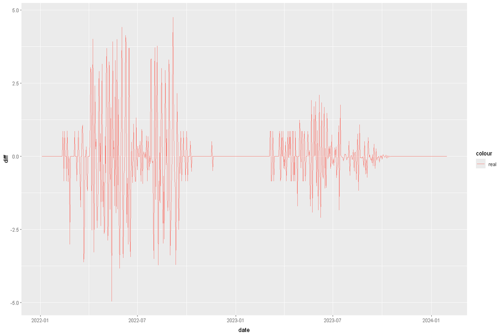

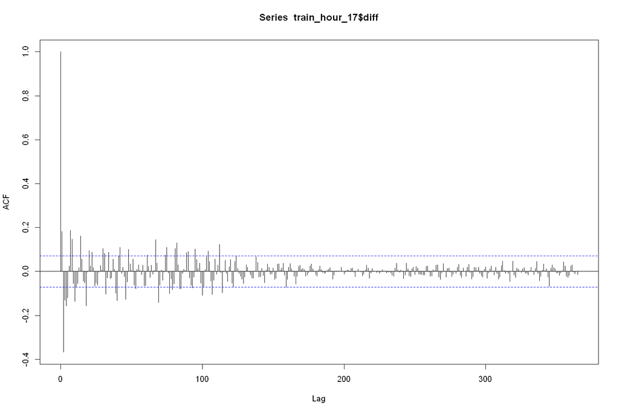

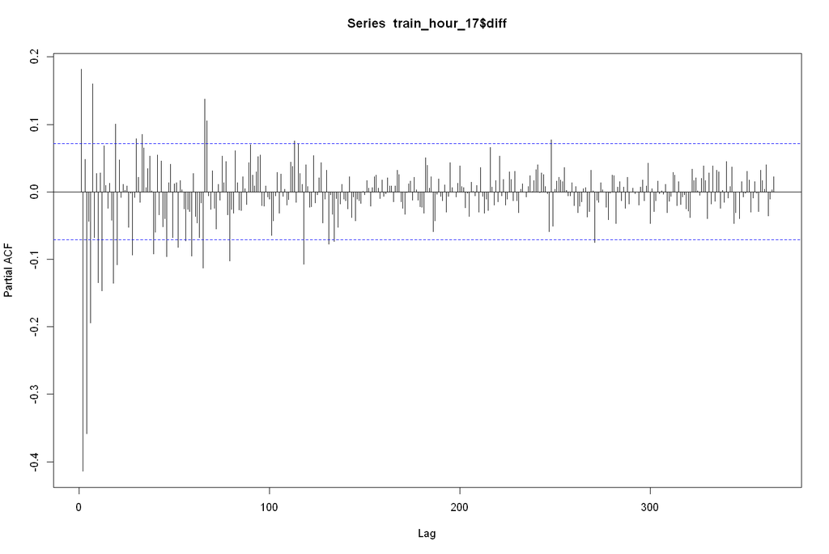

```r
train_hour_17 <- train_split_data_tables[["17"]]
test_hour_17 <- test_split_data_tables[["17"]]

train_hour_17 <- na.omit(train_hour_17)
train_hour_17[,diff:=production - prod_lag_24]

ggplot(train_hour_17,aes(x=date)) + geom_line(aes(y=diff,color='real'))
acf(train_hour_17$diff,lag.max = 365)
pacf(train_hour_17$diff,lag.max = 365)
```

```r
# Fit a simple ARIMA model without external regressors
simple_model <- auto.arima(train_hour_17$diff)
print(summary(simple_model))
```

```
Series: train_hour_17$diff
ARIMA(1,0,2) with zero mean

Coefficients:
         ar1     ma1      ma2
      0.2828  0.0884  -0.7587
s.e.  0.0516  0.0351   0.0281

sigma^2 = 0.7331:  log likelihood = -956.05
AIC=1920.11   AICc=1920.16   BIC=1938.63

Training set error measures:
                      ME      RMSE       MAE MPE MAPE      MASE       ACF1
Training set -0.03342719 0.8545149 0.4667406 NaN  Inf 0.6739808 -0.0109336
```

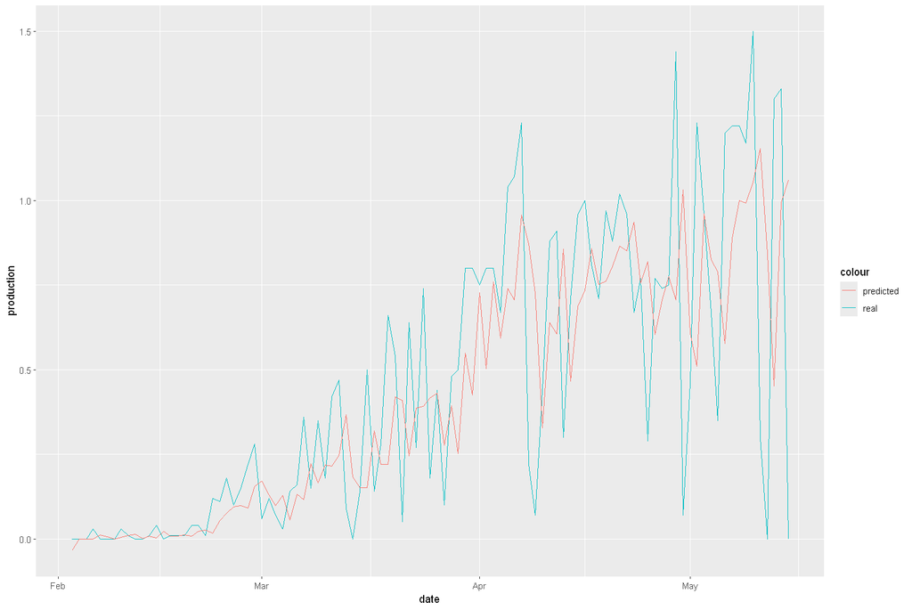

```r
train_model <- Arima(train_hour_17$diff, order = c(1, 0, 2))
test_hour_17[,diff:=production - prod_lag_24]

predictions <- numeric(nrow(test_hour_17))

for (i in 1:nrow(test_hour_17)) {
  # Generate forecast for the next step using the model
  forecast_step <- forecast(train_model, h = 1)

  # Store the forecasted value
  predictions[i] <- forecast_step$mean

  new_data <- c(train_hour_17$diff, test_hour_17$diff[1:i])

  # Refit the model to include the new data
  train_model <- auto.arima(new_data)
}

test_hour_17[,predicted:= prod_lag_24 + predictions]

ggplot(test_hour_17,aes(x=date)) + geom_line(aes(y=production,color='real')) + geom_line(aes(y=predicted,color='predicted'))
```

## Results

```r
arima_results <- rbind(test_hour_6, test_hour_7,test_hour_8,test_hour_9,test_hour_10,test_hour_11,test_hour_12,test_hour_13,test_hour_14,test_hour_15,test_hour_16,test_hour_17)
arima_results
```

A data.table: 1236 × 263

| date <IDate> | hour <int> | csnow_surface_37.75_34.5 <dbl> | csnow_surface_37.75_34.75 <dbl> | csnow_surface_37.75_35.0 <dbl> | csnow_surface_37.75_35.25 <dbl> | csnow_surface_37.75_35.5 <dbl> | csnow_surface_38.0_34.5 <dbl> | csnow_surface_38.0_34.75 <dbl> | csnow_surface_38.0_35.0 <dbl> | ⋯ | hour_transformed <dbl> | prod_lag_24 <dbl> | prod_lag_36 <dbl> | max_production <dbl> | avg_tmp <dbl> | avg_temp_lag_1 <dbl> | avg_temp_lag_2 <dbl> | avg_temp_lag_3 <dbl> | diff <dbl> | predicted <dbl> |
| --- | --- | --- | --- | --- | --- | --- | --- | --- | --- | --- | --- | --- | --- | --- | --- | --- | --- | --- | --- | --- |
| 2024-02-03 | 6 | 0 | 0 | 0 | 0 | 0 | 0 | 0 | 0 | ⋯ | -36 | 0.01 | 0.01 | 9.89 | 268.3936 | 273.6110 | 276.823 | 278.888 | 0.00 | -0.0002410155 |
| 2024-02-04 | 6 | 0 | 0 | 0 | 0 | 0 | 0 | 0 | 0 | ⋯ | -36 | 0.01 | 0.01 | 9.88 | 270.1280 | 274.4055 | 276.914 | 278.842 | 0.06 | 0.0452451219 |
| 2024-02-05 | 6 | 0 | 1 | 1 | 1 | 0 | 0 | 0 | 1 | ⋯ | -36 | 0.01 | 0.01 | 9.88 | 272.1920 | 275.6120 | 278.194 | 280.482 | -0.01 | 0.0162120337 |
| 2024-02-06 | 6 | 0 | 1 | 0 | 1 | 0 | 1 | 1 | 0 | ⋯ | -36 | 0.07 | 0.01 | 9.83 | 274.2160 | 275.8720 | 277.419 | 278.900 | -0.07 | 0.0480016459 |
| 2024-02-07 | 6 | 0 | 0 | 0 | 0 | 0 | 0 | 0 | 0 | ⋯ | -36 | 0.00 | 0.07 | 9.88 | 271.8670 | 279.9720 | 282.645 | 284.288 | 0.02 | -0.0007174678 |
| 2024-02-08 | 6 | 0 | 0 | 0 | 0 | 0 | 0 | 0 | 0 | ⋯ | -36 | 0.00 | 0.00 | 9.88 | 273.0330 | 281.3080 | 284.621 | 286.642 | 0.06 | 0.0409517248 |
| 2024-02-09 | 6 | 0 | 0 | 0 | 0 | 0 | 0 | 0 | 0 | ⋯ | -36 | 0.02 | 0.00 | 9.88 | 272.7390 | 280.1440 | 282.563 | 284.268 | 0.05 | 0.0128849489 |
| 2024-02-10 | 6 | 0 | 0 | 0 | 0 | 0 | 0 | 0 | 0 | ⋯ | -36 | 0.06 | 0.02 | 9.88 | 272.0060 | 281.4290 | 284.604 | 286.605 | 0.00 | 0.0570348311 |
| 2024-02-11 | 6 | 0 | 0 | 0 | 0 | 0 | 0 | 0 | 0 | ⋯ | -36 | 0.07 | 0.06 | 9.87 | 273.2350 | 282.2620 | 285.258 | 286.980 | 0.01 | 0.0273875602 |
| 2024-02-12 | 6 | 0 | 0 | 0 | 0 | 0 | 0 | 0 | 0 | ⋯ | -36 | 0.06 | 0.07 | 9.87 | 274.5450 | 282.8070 | 286.148 | 288.962 | -0.01 | 0.0648978619 |
| 2024-02-13 | 6 | 0 | 0 | 0 | 1 | 0 | 0 | 0 | 0 | ⋯ | -36 | 0.08 | 0.06 | 9.87 | 277.0230 | 281.6040 | 283.413 | 285.486 | -0.08 | 0.0380162074 |
| 2024-02-14 | 6 | 0 | 0 | 1 | 1 | 0 | 0 | 0 | 1 | ⋯ | -36 | 0.05 | 0.08 | 9.83 | 276.9090 | 282.2550 | 284.084 | 284.726 | -0.02 | 0.0483064710 |
| 2024-02-15 | 6 | 0 | 0 | 0 | 0 | 0 | 0 | 0 | 0 | ⋯ | -36 | 0.00 | 0.05 | 7.42 | 272.6870 | 279.3360 | 279.844 | 280.409 | 0.09 | 0.0249343235 |
| 2024-02-16 | 6 | 0 | 0 | 0 | 0 | 0 | 0 | 0 | 0 | ⋯ | -36 | 0.03 | 0.00 | 9.85 | 273.7000 | 282.4400 | 285.528 | 287.664 | 0.11 | 0.0607742769 |
| 2024-02-17 | 6 | 0 | 1 | 0 | 0 | 0 | 1 | 1 | 1 | ⋯ | -36 | 0.09 | 0.03 | 9.85 | 275.0200 | 282.1390 | 284.876 | 287.368 | -0.08 | 0.0613868608 |
| 2024-02-18 | 6 | 0 | 0 | 0 | 0 | 0 | 1 | 1 | 1 | ⋯ | -36 | 0.14 | 0.09 | 9.85 | 272.4570 | 280.7420 | 283.284 | 285.864 | -0.13 | 0.0655580426 |
| 2024-02-19 | 6 | 0 | 0 | 0 | 0 | 0 | 0 | 1 | 1 | ⋯ | -36 | 0.01 | 0.14 | 8.36 | 272.4940 | 278.9350 | 281.173 | 283.028 | 0.05 | 0.0289848438 |
| 2024-02-20 | 6 | 0 | 0 | 0 | 0 | 0 | 0 | 0 | 0 | ⋯ | -36 | 0.01 | 0.01 | 5.75 | 271.1060 | 279.1580 | 281.489 | 282.500 | 0.14 | 0.0615544875 |
| 2024-02-21 | 6 | 0 | 0 | 1 | 1 | 0 | 0 | 0 | 0 | ⋯ | -36 | 0.06 | 0.01 | 9.85 | 272.3000 | 281.2600 | 284.684 | 287.293 | 0.02 | 0.0612818863 |
| 2024-02-22 | 6 | 0 | 0 | 0 | 0 | 0 | 1 | 0 | 0 | ⋯ | -36 | 0.15 | 0.06 | 9.85 | 273.8940 | 282.6080 | 285.905 | 288.328 | -0.09 | 0.0870057499 |
| 2024-02-23 | 6 | 0 | 0 | 0 | 0 | 0 | 0 | 0 | 0 | ⋯ | -36 | 0.08 | 0.15 | 9.85 | 272.4410 | 280.2280 | 281.864 | 284.049 | 0.08 | 0.0533051258 |
| 2024-02-24 | 6 | 0 | 0 | 0 | 0 | 0 | 0 | 0 | 0 | ⋯ | -36 | 0.06 | 0.08 | 9.84 | 271.8340 | 282.8130 | 286.101 | 288.510 | 0.19 | 0.1018068474 |
| 2024-02-25 | 6 | 0 | 0 | 0 | 0 | 0 | 0 | 0 | 0 | ⋯ | -36 | 0.16 | 0.06 | 9.89 | 272.6490 | 283.7080 | 287.198 | 289.528 | 0.12 | 0.1168859259 |
| 2024-02-26 | 6 | 0 | 0 | 0 | 0 | 0 | 0 | 0 | 0 | ⋯ | -36 | 0.25 | 0.16 | 9.89 | 273.3000 | 285.3770 | 289.043 | 291.718 | 0.07 | 0.1692182425 |
| 2024-02-27 | 6 | 0 | 0 | 0 | 0 | 0 | 1 | 0 | 0 | ⋯ | -36 | 0.28 | 0.25 | 9.89 | 275.1360 | 282.8124 | 285.201 | 286.952 | -0.21 | 0.1823169187 |
| 2024-02-28 | 6 | 0 | 0 | 0 | 0 | 0 | 0 | 0 | 0 | ⋯ | -36 | 0.32 | 0.28 | 9.88 | 273.1040 | 285.1840 | 288.443 | 291.119 | 0.13 | 0.1719667496 |
| 2024-02-29 | 6 | 0 | 0 | 0 | 0 | 0 | 0 | 0 | 0 | ⋯ | -36 | 0.07 | 0.32 | 9.88 | 273.2460 | 285.8090 | 289.332 | 291.832 | 0.33 | 0.2014882238 |
| 2024-03-01 | 6 | 0 | 0 | 0 | 0 | 0 | 0 | 0 | 0 | ⋯ | -36 | 0.45 | 0.07 | 9.90 | 273.2080 | 287.1210 | 290.940 | 293.599 | -0.08 | 0.2997168793 |
| 2024-03-02 | 6 | 0 | 0 | 0 | 0 | 0 | 0 | 0 | 0 | ⋯ | -36 | 0.40 | 0.45 | 9.90 | 276.0560 | 287.0030 | 290.779 | 293.797 | -0.23 | 0.2484477994 |
| 2024-03-03 | 6 | 0 | 1 | 0 | 0 | 0 | 0 | 0 | 0 | ⋯ | -36 | 0.37 | 0.40 | 9.90 | 275.9164 | 286.3780 | 289.924 | 292.439 | -0.36 | 0.2855027130 |
| ⋮ | ⋮ | ⋮ | ⋮ | ⋮ | ⋮ | ⋮ | ⋮ | ⋮ | ⋮ | ⋱ | ⋮ | ⋮ | ⋮ | ⋮ | ⋮ | ⋮ | ⋮ | ⋮ | ⋮ | ⋮ |
| 2024-04-16 | 17 | 0 | 0 | 0 | 0 | 0 | 0 | 0 | 0 | ⋯ | -25 | 0.71 | 0.30 | 9.89 | 297.1610 | 300.557 | 303.0470 | 304.6100 | 0.29 | 0.7351826 |
| 2024-04-17 | 17 | 0 | 0 | 0 | 0 | 0 | 0 | 0 | 0 | ⋯ | -25 | 0.96 | 0.71 | 9.89 | 296.0610 | 299.787 | 302.4370 | 304.1550 | -0.15 | 0.8589019 |
| 2024-04-18 | 17 | 0 | 0 | 0 | 0 | 0 | 0 | 0 | 0 | ⋯ | -25 | 1.00 | 0.96 | 9.89 | 295.5520 | 298.088 | 300.5470 | 302.3880 | -0.29 | 0.7523105 |
| 2024-04-19 | 17 | 0 | 0 | 0 | 0 | 0 | 0 | 0 | 0 | ⋯ | -25 | 0.81 | 1.00 | 9.89 | 295.6360 | 299.116 | 301.3980 | 303.0600 | 0.16 | 0.7613551 |
| 2024-04-20 | 17 | 0 | 0 | 0 | 0 | 0 | 0 | 0 | 0 | ⋯ | -25 | 0.71 | 0.81 | 9.88 | 289.7730 | 291.628 | 293.7020 | 294.2220 | 0.17 | 0.8058052 |
| 2024-04-21 | 17 | 0 | 0 | 0 | 0 | 0 | 0 | 0 | 0 | ⋯ | -25 | 0.97 | 0.71 | 9.90 | 294.5300 | 298.244 | 300.9600 | 302.3346 | 0.05 | 0.8663047 |
| 2024-04-22 | 17 | 0 | 0 | 0 | 0 | 0 | 0 | 0 | 0 | ⋯ | -25 | 0.88 | 0.97 | 9.90 | 294.5800 | 298.044 | 301.2250 | 302.9200 | 0.08 | 0.8514613 |
| 2024-04-23 | 17 | 0 | 0 | 0 | 0 | 0 | 0 | 0 | 0 | ⋯ | -25 | 1.02 | 0.88 | 9.90 | 300.0760 | 303.404 | 306.0270 | 307.7880 | -0.35 | 0.9356163 |
| 2024-04-24 | 17 | 0 | 0 | 0 | 0 | 0 | 0 | 0 | 0 | ⋯ | -25 | 0.96 | 1.02 | 9.89 | 299.8120 | 303.772 | 306.3120 | 307.8760 | -0.19 | 0.7551297 |
| 2024-04-25 | 17 | 0 | 0 | 0 | 0 | 0 | 0 | 0 | 0 | ⋯ | -25 | 0.67 | 0.96 | 9.83 | 295.7920 | 298.008 | 300.3450 | 302.7000 | -0.38 | 0.8191755 |
| 2024-04-26 | 17 | 0 | 0 | 0 | 0 | 0 | 0 | 0 | 0 | ⋯ | -25 | 0.77 | 0.67 | 9.70 | 298.2640 | 299.716 | 301.3790 | 302.6320 | 0.00 | 0.6044179 |
| 2024-04-27 | 17 | 0 | 0 | 0 | 0 | 0 | 0 | 0 | 0 | ⋯ | -25 | 0.29 | 0.77 | 9.41 | 298.5520 | 302.017 | 303.3850 | 301.4730 | 0.45 | 0.7061934 |
| 2024-04-28 | 17 | 0 | 0 | 0 | 0 | 0 | 0 | 0 | 0 | ⋯ | -25 | 0.77 | 0.29 | 9.41 | 294.5880 | 296.484 | 298.0640 | 301.0920 | -0.02 | 0.7746516 |
| 2024-04-29 | 17 | 0 | 0 | 0 | 0 | 0 | 0 | 0 | 0 | ⋯ | -25 | 0.74 | 0.77 | 9.39 | 295.5520 | 296.424 | 299.8930 | 300.1460 | 0.70 | 0.7065264 |
| 2024-04-30 | 17 | 0 | 0 | 0 | 0 | 0 | 0 | 0 | 0 | ⋯ | -25 | 0.75 | 0.74 | 9.39 | 292.7010 | 296.016 | 300.3540 | 301.2850 | -0.68 | 1.0313422 |
| 2024-05-01 | 17 | 0 | 0 | 0 | 0 | 0 | 0 | 0 | 0 | ⋯ | -25 | 1.44 | 0.75 | 9.39 | 290.4240 | 292.244 | 294.5250 | 295.0880 | -0.98 | 0.6068537 |
| 2024-05-02 | 17 | 0 | 0 | 0 | 0 | 0 | 0 | 0 | 0 | ⋯ | -25 | 0.07 | 1.44 | 9.23 | 293.1680 | 295.276 | 297.6450 | 299.6280 | 1.16 | 0.5105183 |
| 2024-05-03 | 17 | 0 | 0 | 0 | 0 | 0 | 0 | 0 | 0 | ⋯ | -25 | 0.46 | 0.07 | 8.60 | 288.4200 | 290.272 | 291.6800 | 293.3960 | 0.50 | 0.9612962 |
| 2024-05-04 | 17 | 0 | 0 | 0 | 0 | 0 | 0 | 0 | 0 | ⋯ | -25 | 1.23 | 0.46 | 8.95 | 289.0830 | 290.480 | 292.1850 | 293.2710 | -0.56 | 0.8241054 |
| 2024-05-05 | 17 | 0 | 0 | 1 | 1 | 0 | 0 | 0 | 0 | ⋯ | -25 | 0.96 | 1.23 | 8.95 | 280.9910 | 281.564 | 282.3680 | 284.3946 | -0.61 | 0.7900716 |
| 2024-05-06 | 17 | 0 | 0 | 0 | 0 | 0 | 0 | 0 | 0 | ⋯ | -25 | 0.67 | 0.96 | 9.75 | 287.2240 | 290.396 | 293.0050 | 294.3400 | 0.53 | 0.5765287 |
| 2024-05-07 | 17 | 0 | 0 | 0 | 0 | 0 | 0 | 0 | 0 | ⋯ | -25 | 0.35 | 0.67 | 9.75 | 290.6560 | 293.596 | 296.0590 | 296.8410 | 0.87 | 0.8883774 |
| 2024-05-08 | 17 | 0 | 0 | 0 | 0 | 0 | 0 | 0 | 0 | ⋯ | -25 | 1.20 | 0.35 | 9.89 | 294.5760 | 297.716 | 300.0260 | 301.2360 | 0.02 | 1.0001198 |
| 2024-05-09 | 17 | 0 | 0 | 0 | 0 | 0 | 0 | 0 | 0 | ⋯ | -25 | 1.22 | 1.20 | 9.89 | 292.2140 | 294.403 | 295.3780 | 296.2740 | -0.05 | 0.9935222 |
| 2024-05-10 | 17 | 0 | 0 | 0 | 0 | 0 | 0 | 0 | 0 | ⋯ | -25 | 1.22 | 1.22 | 9.89 | 295.0892 | 298.100 | 300.5920 | 301.7920 | 0.28 | 1.0548350 |
| 2024-05-11 | 17 | 0 | 0 | 0 | 0 | 0 | 0 | 0 | 0 | ⋯ | -25 | 1.17 | 1.22 | 9.85 | 290.9360 | 293.498 | 296.8697 | 298.3970 | -0.87 | 1.1545072 |
| 2024-05-12 | 17 | 0 | 0 | 0 | 0 | 0 | 0 | 0 | 0 | ⋯ | -25 | 1.50 | 1.17 | 9.85 | 287.1706 | 289.478 | 291.4680 | 292.2490 | -1.50 | 0.8418447 |
| 2024-05-13 | 17 | 0 | 0 | 0 | 0 | 0 | 0 | 0 | 0 | ⋯ | -25 | 0.30 | 1.50 | 9.85 | 287.4060 | 288.214 | 289.2990 | 290.9030 | 1.00 | 0.4517888 |
| 2024-05-14 | 17 | 0 | 0 | 0 | 0 | 0 | 0 | 0 | 0 | ⋯ | -25 | 0.00 | 0.30 | 9.70 | 290.5680 | 293.624 | 295.7570 | 296.8120 | 1.33 | 0.9950127 |
| 2024-05-15 | 17 | 0 | 0 | 0 | 0 | 0 | 0 | 0 | 0 | ⋯ | -25 | 1.30 | 0.00 | 9.87 | 292.5800 | 295.492 | 298.0160 | 300.1656 | -1.30 | 1.0593383 |

```r
arima_results <- arima_results %>%
  arrange(date, hour)

arima_results
```

A data.table: 1236 × 263

| date <IDate> | hour <int> | csnow_surface_37.75_34.5 <dbl> | csnow_surface_37.75_34.75 <dbl> | csnow_surface_37.75_35.0 <dbl> | csnow_surface_37.75_35.25 <dbl> | csnow_surface_37.75_35.5 <dbl> | csnow_surface_38.0_34.5 <dbl> | csnow_surface_38.0_34.75 <dbl> | csnow_surface_38.0_35.0 <dbl> | ⋯ | hour_transformed <dbl> | prod_lag_24 <dbl> | prod_lag_36 <dbl> | max_production <dbl> | avg_tmp <dbl> | avg_temp_lag_1 <dbl> | avg_temp_lag_2 <dbl> | avg_temp_lag_3 <dbl> | diff <dbl> | predicted <dbl> |
| --- | --- | --- | --- | --- | --- | --- | --- | --- | --- | --- | --- | --- | --- | --- | --- | --- | --- | --- | --- | --- |
| 2024-02-03 | 6 | 0 | 0 | 0 | 0 | 0 | 0 | 0 | 0 | ⋯ | -36 | 0.01 | 0.01 | 9.89 | 268.3936 | 273.6110 | 276.8230 | 278.8880 | 0.00 | -2.410155e-04 |
| 2024-02-03 | 7 | 0 | 0 | 0 | 0 | 0 | 0 | 0 | 0 | ⋯ | -25 | 1.59 | 0.79 | 9.89 | 268.4030 | 268.3936 | 273.6110 | 276.8230 | -0.65 | 2.018925e+00 |
| 2024-02-03 | 8 | 0 | 0 | 0 | 0 | 0 | 0 | 0 | 0 | ⋯ | -16 | 6.17 | 5.60 | 9.89 | 268.9020 | 268.4030 | 268.3936 | 273.6110 | -1.96 | 9.718954e+00 |
| 2024-02-03 | 9 | 0 | 0 | 0 | 0 | 0 | 0 | 0 | 0 | ⋯ | -9 | 7.11 | 8.86 | 9.89 | 271.7370 | 268.9020 | 268.4030 | 268.3936 | -0.28 | 9.902075e+00 |
| 2024-02-03 | 10 | 0 | 0 | 0 | 0 | 0 | 0 | 0 | 0 | ⋯ | -4 | 5.20 | 9.89 | 9.88 | 275.0200 | 271.7370 | 268.9020 | 268.4030 | 0.91 | 9.896811e+00 |
| 2024-02-03 | 11 | 0 | 0 | 0 | 0 | 0 | 0 | 0 | 0 | ⋯ | -1 | 3.53 | 9.85 | 9.88 | 277.6590 | 275.0200 | 271.7370 | 268.9020 | 5.56 | 8.432846e+00 |
| 2024-02-03 | 12 | 0 | 0 | 0 | 0 | 0 | 0 | 0 | 0 | ⋯ | 0 | 4.92 | 9.83 | 9.88 | 279.6090 | 277.6590 | 275.0200 | 271.7370 | 3.79 | 8.715851e+00 |
| 2024-02-03 | 13 | 0 | 0 | 0 | 0 | 0 | 0 | 0 | 0 | ⋯ | -1 | 4.90 | 9.73 | 9.88 | 280.5390 | 279.6090 | 277.6590 | 275.0200 | 3.12 | 9.544334e+00 |
| 2024-02-03 | 14 | 0 | 0 | 0 | 0 | 0 | 0 | 0 | 0 | ⋯ | -4 | 5.78 | 5.11 | 9.88 | 280.0790 | 280.5390 | 279.6090 | 277.6590 | -1.41 | 6.382727e+00 |
| 2024-02-03 | 15 | 0 | 0 | 0 | 0 | 0 | 0 | 0 | 0 | ⋯ | -9 | 4.78 | 2.35 | 9.88 | 278.8420 | 280.0790 | 280.5390 | 279.6090 | -1.54 | 4.245336e+00 |
| 2024-02-03 | 16 | 0 | 0 | 0 | 1 | 1 | 0 | 0 | 0 | ⋯ | -16 | 0.53 | 0.62 | 9.88 | 276.9140 | 278.8420 | 280.0790 | 280.5390 | 0.41 | 3.044991e-01 |
| 2024-02-03 | 17 | 0 | 0 | 0 | 1 | 1 | 0 | 0 | 0 | ⋯ | -25 | 0.00 | 0.00 | 9.88 | 274.4055 | 276.9140 | 278.8420 | 280.0790 | 0.00 | -3.449622e-02 |
| 2024-02-04 | 6 | 0 | 0 | 0 | 0 | 0 | 0 | 0 | 0 | ⋯ | -36 | 0.01 | 0.01 | 9.88 | 270.1280 | 274.4055 | 276.9140 | 278.8420 | 0.06 | 4.524512e-02 |
| 2024-02-04 | 7 | 0 | 0 | 0 | 0 | 0 | 0 | 0 | 0 | ⋯ | -25 | 1.62 | 1.59 | 9.88 | 269.9900 | 270.1280 | 274.4055 | 276.9140 | -0.59 | 1.044907e+00 |
| 2024-02-04 | 8 | 0 | 0 | 0 | 0 | 0 | 0 | 0 | 0 | ⋯ | -16 | 6.15 | 6.17 | 9.88 | 270.2840 | 269.9900 | 270.1280 | 274.4055 | -1.11 | 1.068623e+00 |
| 2024-02-04 | 9 | 0 | 0 | 0 | 0 | 0 | 0 | 0 | 0 | ⋯ | -9 | 9.03 | 7.11 | 9.88 | 272.9410 | 270.2840 | 269.9900 | 270.1280 | -0.01 | 6.014117e+00 |
| 2024-02-04 | 10 | 0 | 0 | 0 | 0 | 0 | 0 | 0 | 0 | ⋯ | -4 | 9.85 | 5.20 | 9.88 | 276.2170 | 272.9410 | 270.2840 | 269.9900 | -0.02 | 6.342598e+00 |
| 2024-02-04 | 11 | 0 | 0 | 0 | 0 | 0 | 0 | 0 | 0 | ⋯ | -1 | 9.88 | 3.53 | 9.88 | 279.0930 | 276.2170 | 272.9410 | 270.2840 | -2.92 | 7.254440e+00 |
| 2024-02-04 | 12 | 0 | 0 | 0 | 0 | 0 | 0 | 0 | 0 | ⋯ | 0 | 9.85 | 4.92 | 9.88 | 281.4240 | 279.0930 | 276.2170 | 272.9410 | -0.66 | 7.782216e+00 |
| 2024-02-04 | 13 | 0 | 0 | 0 | 0 | 1 | 0 | 0 | 0 | ⋯ | -1 | 9.85 | 4.90 | 9.88 | 282.2740 | 281.4240 | 279.0930 | 276.2170 | -0.85 | 8.369267e+00 |
| 2024-02-04 | 14 | 0 | 0 | 0 | 0 | 1 | 0 | 0 | 0 | ⋯ | -4 | 8.85 | 5.78 | 9.88 | 281.7200 | 282.2740 | 281.4240 | 279.0930 | -5.60 | 7.630916e+00 |
| 2024-02-04 | 15 | 0 | 0 | 0 | 0 | 1 | 0 | 0 | 0 | ⋯ | -9 | 5.64 | 4.78 | 9.88 | 280.4820 | 281.7200 | 282.2740 | 281.4240 | -1.93 | 5.604349e+00 |
| 2024-02-04 | 16 | 0 | 0 | 0 | 1 | 0 | 0 | 0 | 0 | ⋯ | -16 | 1.53 | 0.53 | 9.88 | 278.1940 | 280.4820 | 281.7200 | 282.2740 | -0.87 | 1.724874e+00 |
| 2024-02-04 | 17 | 0 | 0 | 0 | 1 | 0 | 0 | 0 | 0 | ⋯ | -25 | 0.00 | 0.00 | 9.88 | 275.6120 | 278.1940 | 280.4820 | 281.7200 | 0.00 | -1.078631e-06 |
| 2024-02-05 | 6 | 0 | 1 | 1 | 1 | 0 | 0 | 0 | 1 | ⋯ | -36 | 0.01 | 0.01 | 9.88 | 272.1920 | 275.6120 | 278.1940 | 280.4820 | -0.01 | 1.621203e-02 |
| 2024-02-05 | 7 | 0 | 1 | 1 | 1 | 0 | 0 | 0 | 1 | ⋯ | -25 | 0.94 | 1.62 | 9.88 | 271.4000 | 272.1920 | 275.6120 | 278.1940 | -0.06 | 1.558084e+00 |
| 2024-02-05 | 8 | 0 | 1 | 0 | 1 | 0 | 0 | 0 | 1 | ⋯ | -16 | 4.21 | 6.15 | 9.88 | 271.3510 | 271.4000 | 272.1920 | 275.6120 | -1.20 | 7.905319e+00 |
| 2024-02-05 | 9 | 0 | 1 | 0 | 0 | 0 | 0 | 0 | 1 | ⋯ | -9 | 6.83 | 9.03 | 9.88 | 273.4940 | 271.3510 | 271.4000 | 272.1920 | -2.62 | 1.059721e+01 |
| 2024-02-05 | 10 | 0 | 1 | 0 | 0 | 0 | 1 | 0 | 0 | ⋯ | -4 | 6.11 | 9.85 | 9.88 | 276.0780 | 273.4940 | 271.3510 | 271.4000 | 0.58 | 9.219619e+00 |
| 2024-02-05 | 11 | 0 | 1 | 1 | 0 | 0 | 1 | 0 | 0 | ⋯ | -1 | 9.09 | 9.88 | 9.85 | 278.0010 | 276.0780 | 273.4940 | 271.3510 | -4.97 | 8.304253e+00 |
| ⋮ | ⋮ | ⋮ | ⋮ | ⋮ | ⋮ | ⋮ | ⋮ | ⋮ | ⋮ | ⋱ | ⋮ | ⋮ | ⋮ | ⋮ | ⋮ | ⋮ | ⋮ | ⋮ | ⋮ | ⋮ |
| 2024-05-13 | 12 | 0 | 0 | 0 | 0 | 0 | 0 | 0 | 0 | ⋯ | 0 | 2.25 | 8.29 | 9.85 | 291.7600 | 289.8190 | 287.0340 | 285.0270 | 3.09 | 4.4925461 |
| 2024-05-13 | 13 | 0 | 0 | 0 | 0 | 0 | 0 | 0 | 0 | ⋯ | -1 | 3.67 | 6.97 | 9.85 | 292.6850 | 291.7600 | 289.8190 | 287.0340 | 0.37 | -0.6272003 |
| 2024-05-13 | 14 | 0 | 0 | 0 | 0 | 0 | 0 | 0 | 0 | ⋯ | -4 | 1.91 | 6.13 | 9.85 | 290.9030 | 292.6850 | 291.7600 | 289.8190 | 3.98 | 3.9255398 |
| 2024-05-13 | 15 | 0 | 0 | 0 | 0 | 0 | 0 | 0 | 0 | ⋯ | -9 | 1.24 | 3.94 | 9.85 | 289.2990 | 290.9030 | 292.6850 | 291.7600 | 4.08 | 2.4338590 |
| 2024-05-13 | 16 | 0 | 0 | 0 | 0 | 0 | 0 | 0 | 0 | ⋯ | -16 | 0.78 | 2.38 | 9.85 | 288.2140 | 289.2990 | 290.9030 | 292.6850 | 2.84 | 1.3429215 |
| 2024-05-13 | 17 | 0 | 0 | 0 | 0 | 0 | 0 | 0 | 0 | ⋯ | -25 | 0.30 | 1.50 | 9.85 | 287.4060 | 288.2140 | 289.2990 | 290.9030 | 1.00 | 0.4517888 |
| 2024-05-14 | 6 | 0 | 0 | 1 | 0 | 0 | 0 | 0 | 0 | ⋯ | -36 | 0.00 | 2.51 | 9.85 | 277.9880 | 287.4060 | 288.2140 | 289.2990 | 2.59 | 2.2274169 |
| 2024-05-14 | 7 | 0 | 1 | 1 | 0 | 0 | 0 | 0 | 0 | ⋯ | -25 | 0.00 | 6.27 | 9.85 | 279.1590 | 277.9880 | 287.4060 | 288.2140 | 4.14 | 4.5339772 |
| 2024-05-14 | 8 | 0 | 1 | 1 | 0 | 0 | 0 | 1 | 1 | ⋯ | -16 | 0.00 | 9.07 | 9.85 | 281.5176 | 279.1590 | 277.9880 | 287.4060 | 7.60 | 6.5482138 |
| 2024-05-14 | 9 | 0 | 1 | 1 | 0 | 0 | 1 | 0 | 1 | ⋯ | -9 | 0.00 | 9.85 | 9.54 | 285.1400 | 281.5176 | 279.1590 | 277.9880 | 8.83 | 6.8304326 |
| 2024-05-14 | 10 | 0 | 0 | 0 | 0 | 0 | 0 | 0 | 0 | ⋯ | -4 | 0.00 | 9.54 | 9.24 | 289.0200 | 285.1400 | 281.5176 | 279.1590 | 7.44 | 6.8141203 |
| 2024-05-14 | 11 | 0 | 0 | 0 | 0 | 0 | 0 | 0 | 0 | ⋯ | -1 | 0.00 | 5.76 | 9.24 | 292.4280 | 289.0200 | 285.1400 | 281.5176 | 5.84 | 6.9751032 |
| 2024-05-14 | 12 | 0 | 0 | 0 | 0 | 0 | 0 | 0 | 0 | ⋯ | 0 | 0.00 | 2.25 | 9.24 | 295.2680 | 292.4280 | 289.0200 | 285.1400 | 7.78 | 6.5884775 |
| 2024-05-14 | 13 | 0 | 0 | 0 | 0 | 0 | 0 | 0 | 0 | ⋯ | -1 | 0.00 | 3.67 | 9.64 | 296.5270 | 295.2680 | 292.4280 | 289.0200 | 9.64 | 4.5836235 |
| 2024-05-14 | 14 | 0 | 0 | 0 | 0 | 0 | 0 | 0 | 0 | ⋯ | -4 | 0.00 | 1.91 | 9.70 | 296.8120 | 296.5270 | 295.2680 | 292.4280 | 9.70 | 6.0486969 |
| 2024-05-14 | 15 | 0 | 0 | 0 | 0 | 0 | 0 | 0 | 0 | ⋯ | -9 | 0.00 | 1.24 | 9.70 | 295.7570 | 296.8120 | 296.5270 | 295.2680 | 7.82 | 4.8239343 |
| 2024-05-14 | 16 | 0 | 0 | 0 | 0 | 0 | 0 | 0 | 0 | ⋯ | -16 | 0.00 | 0.78 | 9.70 | 293.6240 | 295.7570 | 296.8120 | 296.5270 | 4.55 | 3.1009750 |
| 2024-05-14 | 17 | 0 | 0 | 0 | 0 | 0 | 0 | 0 | 0 | ⋯ | -25 | 0.00 | 0.30 | 9.70 | 290.5680 | 293.6240 | 295.7570 | 296.8120 | 1.33 | 0.9950127 |
| 2024-05-15 | 6 | 0 | 0 | 0 | 0 | 0 | 0 | 0 | 0 | ⋯ | -36 | 2.69 | 0.00 | 9.70 | 277.9850 | 290.5680 | 293.6240 | 295.7570 | 0.25 | 2.2529689 |
| 2024-05-15 | 7 | 0 | 0 | 0 | 0 | 0 | 0 | 0 | 0 | ⋯ | -25 | 5.75 | 0.00 | 9.70 | 281.3370 | 277.9850 | 290.5680 | 293.6240 | 0.83 | 4.6626799 |
| 2024-05-15 | 8 | 0 | 0 | 0 | 0 | 0 | 0 | 0 | 0 | ⋯ | -16 | 9.24 | 0.00 | 9.70 | 285.4930 | 281.3370 | 277.9850 | 290.5680 | -0.11 | 7.5294905 |
| 2024-05-15 | 9 | 0 | 0 | 0 | 0 | 0 | 0 | 0 | 0 | ⋯ | -9 | 8.88 | 0.00 | 9.82 | 290.0600 | 285.4930 | 281.3370 | 277.9850 | 0.94 | 7.8785858 |
| 2024-05-15 | 10 | 0 | 0 | 0 | 0 | 0 | 0 | 0 | 0 | ⋯ | -4 | 7.85 | 0.00 | 9.87 | 295.1730 | 290.0600 | 285.4930 | 281.3370 | 2.02 | 7.8242332 |
| 2024-05-15 | 11 | 0 | 0 | 0 | 0 | 0 | 0 | 0 | 0 | ⋯ | -1 | 8.36 | 0.00 | 9.87 | 299.4520 | 295.1730 | 290.0600 | 285.4930 | 1.46 | 6.8693764 |
| 2024-05-15 | 12 | 0 | 0 | 0 | 0 | 0 | 0 | 0 | 0 | ⋯ | 0 | 5.34 | 0.00 | 9.87 | 301.1160 | 299.4520 | 295.1730 | 290.0600 | 2.58 | 6.2691266 |
| 2024-05-15 | 13 | 0 | 0 | 0 | 0 | 0 | 0 | 0 | 0 | ⋯ | -1 | 4.04 | 0.00 | 9.87 | 301.0770 | 301.1160 | 299.4520 | 295.1730 | 3.14 | 9.0226440 |
| 2024-05-15 | 14 | 0 | 0 | 0 | 0 | 0 | 0 | 0 | 0 | ⋯ | -4 | 5.89 | 0.00 | 9.87 | 300.1656 | 301.0770 | 301.1160 | 299.4520 | 0.11 | 6.4788289 |
| 2024-05-15 | 15 | 0 | 0 | 0 | 0 | 0 | 0 | 0 | 0 | ⋯ | -9 | 5.32 | 0.00 | 9.87 | 298.0160 | 300.1656 | 301.0770 | 301.1160 | -2.21 | 4.8897714 |
| 2024-05-15 | 16 | 0 | 0 | 0 | 0 | 0 | 0 | 0 | 0 | ⋯ | -16 | 3.62 | 0.00 | 9.87 | 295.4920 | 298.0160 | 300.1656 | 301.0770 | -3.62 | 2.9962668 |
| 2024-05-15 | 17 | 0 | 0 | 0 | 0 | 0 | 0 | 0 | 0 | ⋯ | -25 | 1.30 | 0.00 | 9.87 | 292.5800 | 295.4920 | 298.0160 | 300.1656 | -1.30 | 1.0593383 |

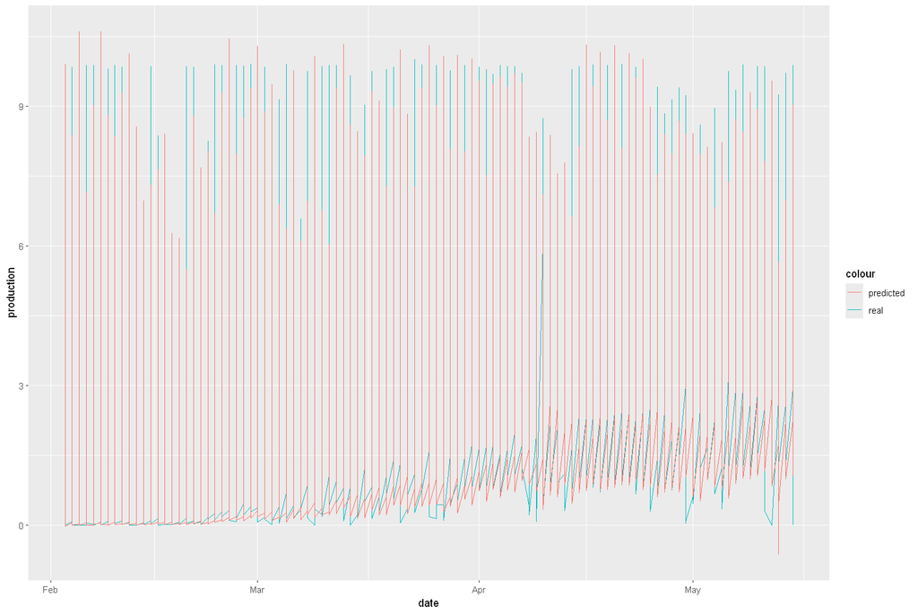

```r
ggplot(arima_results,aes(x=date)) + geom_line(aes(y=production,color='real')) + geom_line(aes(y=predicted,color='predicted'))
```

```
	Ljung-Box test

data:  Residuals
Q* = 1600, df = 10, p-value < 2.2e-16

Model df: 0.   Total lags used: 10
```

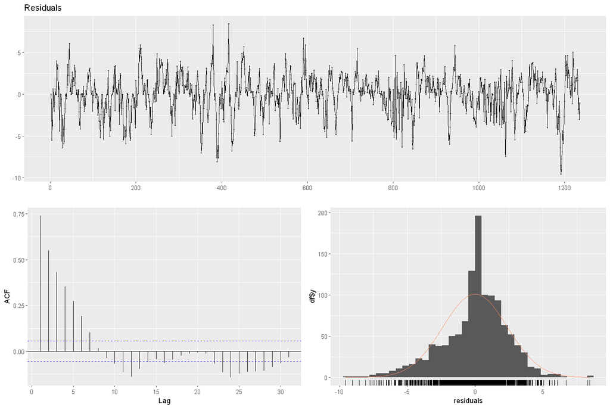

```r
arima_results[,residual:=production-predicted]
checkresiduals(arima_results$residual)
```

```r
accu5 <- accu("5. ARIMA for each hour", arima_results$production, arima_results$predicted)
comparisons <- rbind(comparisons, accu5)
comparisons
```

A data.frame: 6 × 11

| model <chr> | n <int> | mean <dbl> | sd <dbl> | CV <dbl> | FBias <dbl> | MAPE <dbl> | RMSE <dbl> | MAD <dbl> | MADP <dbl> | WMAPE <dbl> |
| --- | --- | --- | --- | --- | --- | --- | --- | --- | --- | --- |
| 0. Baseline-LM | 1269 | 5.060165 | 3.389830 | 0.6699049 | 0.1048254650 | 4469.314 | 1.993499 | 1.564115 | 0.3091036 | 0.3091036 |
| 1. Lasso(1sd)-LM | 1269 | 5.060165 | 3.389830 | 0.6699049 | 0.1088095279 | 4058.146 | 1.994581 | 1.573241 | 0.3109070 | 0.3109070 |
| 2. Lasso(1sd) - LM_lag10 (IM) | 1262 | 5.044160 | 3.386026 | 0.6712765 | 0.0745083684 | 4407.538 | 1.908707 | 1.505325 | 0.2984292 | 0.2984292 |
| 3. Lasso(1sd)-LM_lag24_lag36 | 1236 | 5.055283 | 3.381461 | 0.6688964 | 0.0809165157 | 4201.848 | 1.906118 | 1.493561 | 0.2954455 | 0.2954455 |
| 4. Lasso(3sd)-LM_lag24_lag36 | 1236 | 5.055283 | 3.381461 | 0.6688964 | 0.0991611324 | 4422.851 | 1.946731 | 1.549387 | 0.3064887 | 0.3064887 |
| 5. ARIMA for each hour | 1236 | 5.055283 | 3.381461 | 0.6688964 | 0.0007428499 | 6006.657 | 2.373454 | 1.752375 | 0.3466422 | 0.3466422 |

# Sixth Approach : ARIMA for overall data

filtered_data is the training set with only lasso variables (1sd)

```r
setDT(filtered_data)
filtered_data[,diff:=production - prod_lag_24]

# Fit a simple ARIMA model without external regressors
simple_model <- auto.arima(filtered_data$diff)
print(summary(simple_model))
```

```
Series: filtered_data$diff
ARIMA(2,0,1) with zero mean

Coefficients:
         ar1     ar2     ma1
      0.1110  0.4437  0.5785
s.e.  0.1328  0.0926  0.1356

sigma^2 = 3.968:  log likelihood = -19165.18
AIC=38338.37   AICc=38338.37   BIC=38366.83

Training set error measures:
                       ME     RMSE      MAE MPE MAPE     MASE        ACF1
Training set 0.0002259789 1.991602 1.335724 NaN  Inf 0.932293 0.003566144
```

Auto.arima function found ARIMA (2,0,1) as the best fit. It uses autoregressive terms at lag 1 and lag 2, and the last residual value (MA1). We are predicting the 2-days differences. In this context, the autoregressive value at lag 1 for hour 14 is the 2-days difference of the previous hour, 13. However, we do not know this information yet in the forecasting setting. Therefore, ARIMA (2,0,1) model for overall data is impractical for our case.

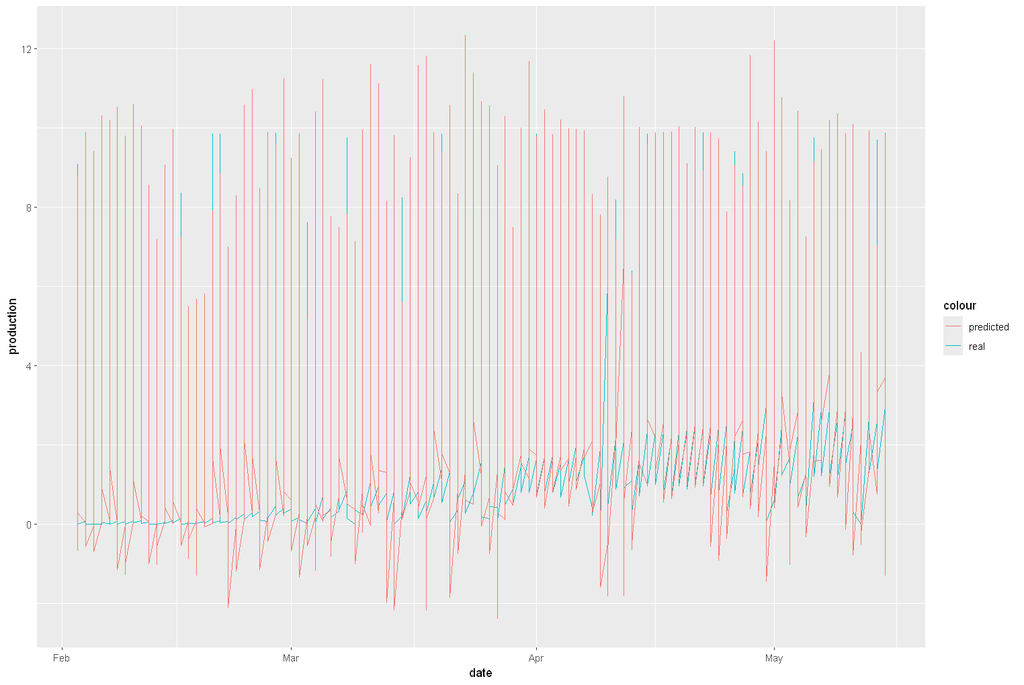

```r
train_model <- Arima(filtered_data$diff, order = c(2, 0, 1))
test_data[,diff:=production - prod_lag_24]

predictions <- numeric(nrow(test_data))

for (i in 1:nrow(test_data)) {
  # Generate forecast for the next step using the model
  forecast_step <- forecast(train_model, h = 1)

  # Store the forecasted value
  predictions[i] <- forecast_step$mean

  new_data <- c(filtered_data$diff, test_data$diff[1:i])

  # Refit the model to include the new data
  train_model <- Arima(new_data, order = c(2, 0, 1))
}

sixth_model_evaluation <- copy(test_data)
sixth_model_evaluation[,predicted:= prod_lag_24 + predictions]

ggplot(sixth_model_evaluation,aes(x=date)) + geom_line(aes(y=production,color='real')) + geom_line(aes(y=predicted,color='predicted'))
```

```
	Ljung-Box test

data:  Residuals
Q* = 53.126, df = 10, p-value = 7.056e-08

Model df: 0.   Total lags used: 10
```

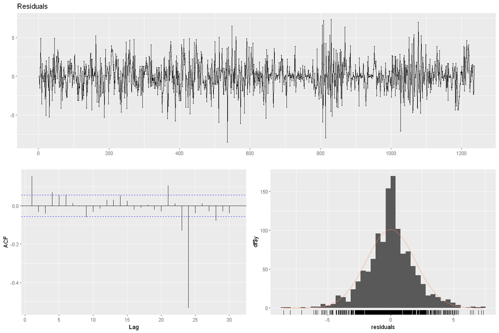

```r
sixth_model_evaluation[,residual:=production-predicted]
checkresiduals(sixth_model_evaluation$residual)
```

```r
accu6 <- accu("6. ARIMA for overall (IM)", sixth_model_evaluation$production, sixth_model_evaluation$predicted)
comparisons <- rbind(comparisons, accu6)
comparisons
```

A data.frame: 7 × 11

| model <chr> | n <int> | mean <dbl> | sd <dbl> | CV <dbl> | FBias <dbl> | MAPE <dbl> | RMSE <dbl> | MAD <dbl> | MADP <dbl> | WMAPE <dbl> |
| --- | --- | --- | --- | --- | --- | --- | --- | --- | --- | --- |
| 0. Baseline-LM | 1269 | 5.060165 | 3.389830 | 0.6699049 | 0.1048254650 | 4469.314 | 1.993499 | 1.564115 | 0.3091036 | 0.3091036 |
| 1. Lasso(1sd)-LM | 1269 | 5.060165 | 3.389830 | 0.6699049 | 0.1088095279 | 4058.146 | 1.994581 | 1.573241 | 0.3109070 | 0.3109070 |
| 2. Lasso(1sd) - LM_lag10 (IM) | 1262 | 5.044160 | 3.386026 | 0.6712765 | 0.0745083684 | 4407.538 | 1.908707 | 1.505325 | 0.2984292 | 0.2984292 |
| 3. Lasso(1sd)-LM_lag24_lag36 | 1236 | 5.055283 | 3.381461 | 0.6688964 | 0.0809165157 | 4201.848 | 1.906118 | 1.493561 | 0.2954455 | 0.2954455 |
| 4. Lasso(3sd)-LM_lag24_lag36 | 1236 | 5.055283 | 3.381461 | 0.6688964 | 0.0991611324 | 4422.851 | 1.946731 | 1.549387 | 0.3064887 | 0.3064887 |
| 5. ARIMA for each hour | 1236 | 5.055283 | 3.381461 | 0.6688964 | 0.0007428499 | 6006.657 | 2.373454 | 1.752375 | 0.3466422 | 0.3466422 |
| 6. ARIMA for overall (IM) | 1236 | 5.055283 | 3.381461 | 0.6688964 | 0.0012032262 | 3022.291 | 1.935345 | 1.408278 | 0.2785754 | 0.2785754 |

# Conclusion

We will select the third model since it has the lowest WMAPE among the practical models. Let's add the hours that we predict as 0 to the third model, and report the real error measures.

```r
head(third_model_evaluation)
```

A data.table: 6 × 263

| date <IDate> | hour <int> | csnow_surface_37.75_34.5 <dbl> | csnow_surface_37.75_34.75 <dbl> | csnow_surface_37.75_35.0 <dbl> | csnow_surface_37.75_35.25 <dbl> | csnow_surface_37.75_35.5 <dbl> | csnow_surface_38.0_34.5 <dbl> | csnow_surface_38.0_34.75 <dbl> | csnow_surface_38.0_35.0 <dbl> | ⋯ | hour_transformed <dbl> | prod_lag_24 <dbl> | prod_lag_36 <dbl> | max_production <dbl> | avg_tmp <dbl> | avg_temp_lag_1 <dbl> | avg_temp_lag_2 <dbl> | avg_temp_lag_3 <dbl> | predicted <dbl> | residual <dbl> |
| --- | --- | --- | --- | --- | --- | --- | --- | --- | --- | --- | --- | --- | --- | --- | --- | --- | --- | --- | --- | --- |
| 2024-02-03 | 6 | 0 | 0 | 0 | 0 | 0 | 0 | 0 | 0 | ⋯ | -36 | 0.01 | 0.01 | 9.89 | 268.3936 | 273.6110 | 276.8230 | 278.8880 | 0.04655828 | -0.03655828 |
| 2024-02-03 | 7 | 0 | 0 | 0 | 0 | 0 | 0 | 0 | 0 | ⋯ | -25 | 1.59 | 0.79 | 9.89 | 268.4030 | 268.3936 | 273.6110 | 276.8230 | 1.57428819 | -0.63428819 |
| 2024-02-03 | 8 | 0 | 0 | 0 | 0 | 0 | 0 | 0 | 0 | ⋯ | -16 | 6.17 | 5.60 | 9.89 | 268.9020 | 268.4030 | 268.3936 | 273.6110 | 4.00077012 | 0.20922988 |
| 2024-02-03 | 9 | 0 | 0 | 0 | 0 | 0 | 0 | 0 | 0 | ⋯ | -9 | 7.11 | 8.86 | 9.89 | 271.7370 | 268.9020 | 268.4030 | 268.3936 | 5.78179162 | 1.04820838 |
| 2024-02-03 | 10 | 0 | 0 | 0 | 0 | 0 | 0 | 0 | 0 | ⋯ | -4 | 5.20 | 9.89 | 9.88 | 275.0200 | 271.7370 | 268.9020 | 268.4030 | 7.46486361 | -1.35486361 |
| 2024-02-03 | 11 | 0 | 0 | 0 | 0 | 0 | 0 | 0 | 0 | ⋯ | -1 | 3.53 | 9.85 | 9.88 | 277.6590 | 275.0200 | 271.7370 | 268.9020 | 7.47106941 | 1.61893059 |

```r
data_path <- 'real_new_data_16may.csv'

data <- fread(data_path)
colnames(data) <- tolower(colnames(data))

cutoff_date <- as.IDate("2024-02-02")
data <- data[date > cutoff_date]

data <- na.omit(data)
head(data)
tail(data)
str(data)
```

A data.table: 6 × 253

| date <IDate> | hour <int> | csnow_surface_37.75_34.5 <dbl> | csnow_surface_37.75_34.75 <dbl> | csnow_surface_37.75_35.0 <dbl> | csnow_surface_37.75_35.25 <dbl> | csnow_surface_37.75_35.5 <dbl> | csnow_surface_38.0_34.5 <dbl> | csnow_surface_38.0_34.75 <dbl> | csnow_surface_38.0_35.0 <dbl> | ⋯ | uswrf_top_of_atmosphere_38.5_34.75 <dbl> | uswrf_top_of_atmosphere_38.5_35.0 <dbl> | uswrf_top_of_atmosphere_38.5_35.25 <dbl> | uswrf_top_of_atmosphere_38.5_35.5 <dbl> | uswrf_top_of_atmosphere_38.75_34.5 <dbl> | uswrf_top_of_atmosphere_38.75_34.75 <dbl> | uswrf_top_of_atmosphere_38.75_35.0 <dbl> | uswrf_top_of_atmosphere_38.75_35.25 <dbl> | uswrf_top_of_atmosphere_38.75_35.5 <dbl> | production <dbl> |
| --- | --- | --- | --- | --- | --- | --- | --- | --- | --- | --- | --- | --- | --- | --- | --- | --- | --- | --- | --- | --- |
| 2024-02-03 | 0 | 0 | 0 | 0 | 0 | 0 | 0 | 0 | 0 | ⋯ | 0 | 0 | 0 | 0 | 0 | 0 | 0 | 0 | 0 | 0 |
| 2024-02-03 | 1 | 0 | 0 | 0 | 0 | 0 | 0 | 0 | 0 | ⋯ | 0 | 0 | 0 | 0 | 0 | 0 | 0 | 0 | 0 | 0 |
| 2024-02-03 | 2 | 0 | 0 | 0 | 0 | 0 | 0 | 0 | 0 | ⋯ | 0 | 0 | 0 | 0 | 0 | 0 | 0 | 0 | 0 | 0 |
| 2024-02-03 | 3 | 0 | 0 | 0 | 0 | 0 | 0 | 0 | 0 | ⋯ | 0 | 0 | 0 | 0 | 0 | 0 | 0 | 0 | 0 | 0 |
| 2024-02-03 | 4 | 0 | 0 | 0 | 0 | 0 | 0 | 0 | 0 | ⋯ | 0 | 0 | 0 | 0 | 0 | 0 | 0 | 0 | 0 | 0 |
| 2024-02-03 | 5 | 0 | 0 | 0 | 0 | 0 | 0 | 0 | 0 | ⋯ | 0 | 0 | 0 | 0 | 0 | 0 | 0 | 0 | 0 | 0 |

A data.table: 6 × 253

| date <IDate> | hour <int> | csnow_surface_37.75_34.5 <dbl> | csnow_surface_37.75_34.75 <dbl> | csnow_surface_37.75_35.0 <dbl> | csnow_surface_37.75_35.25 <dbl> | csnow_surface_37.75_35.5 <dbl> | csnow_surface_38.0_34.5 <dbl> | csnow_surface_38.0_34.75 <dbl> | csnow_surface_38.0_35.0 <dbl> | ⋯ | uswrf_top_of_atmosphere_38.5_34.75 <dbl> | uswrf_top_of_atmosphere_38.5_35.0 <dbl> | uswrf_top_of_atmosphere_38.5_35.25 <dbl> | uswrf_top_of_atmosphere_38.5_35.5 <dbl> | uswrf_top_of_atmosphere_38.75_34.5 <dbl> | uswrf_top_of_atmosphere_38.75_34.75 <dbl> | uswrf_top_of_atmosphere_38.75_35.0 <dbl> | uswrf_top_of_atmosphere_38.75_35.25 <dbl> | uswrf_top_of_atmosphere_38.75_35.5 <dbl> | production <dbl> |
| --- | --- | --- | --- | --- | --- | --- | --- | --- | --- | --- | --- | --- | --- | --- | --- | --- | --- | --- | --- | --- |
| 2024-05-15 | 18 | 0 | 0 | 0 | 0 | 0 | 0 | 0 | 0 | ⋯ | 219.392 | 298.160 | 280.688 | 216.688 | 189.520 | 202.000 | 204.784 | 236.160 | 217.920 | 0 |
| 2024-05-15 | 19 | 0 | 0 | 0 | 0 | 0 | 0 | 0 | 0 | ⋯ | 192.144 | 251.104 | 236.976 | 196.496 | 166.032 | 178.864 | 183.488 | 208.976 | 193.216 | 0 |
| 2024-05-15 | 20 | 0 | 0 | 0 | 0 | 0 | 0 | 0 | 0 | ⋯ | 159.104 | 205.536 | 194.096 | 161.504 | 138.688 | 148.656 | 151.904 | 171.792 | 159.040 | 0 |
| 2024-05-15 | 21 | 0 | 0 | 0 | 0 | 0 | 0 | 0 | 0 | ⋯ | 132.576 | 171.280 | 161.728 | 134.592 | 115.568 | 123.872 | 126.592 | 143.152 | 132.528 | 0 |
| 2024-05-15 | 22 | 0 | 0 | 0 | 0 | 0 | 0 | 0 | 0 | ⋯ | 0.000 | 0.000 | 0.000 | 0.000 | 0.000 | 0.000 | 0.000 | 0.000 | 0.000 | 0 |
| 2024-05-15 | 23 | 0 | 0 | 0 | 0 | 0 | 0 | 0 | 0 | ⋯ | 0.000 | 0.000 | 0.000 | 0.000 | 0.000 | 0.000 | 0.000 | 0.000 | 0.000 | 0 |

```
Classes 'data.table' and 'data.frame':	2472 obs. of  253 variables:
 $ date                               : IDate, format: "2024-02-03" "2024-02-03" ...
 $ hour                               : int  0 1 2 3 4 5 6 7 8 9 ...
 $ csnow_surface_37.75_34.5           : num  0 0 0 0 0 0 0 0 0 0 ...
 $ csnow_surface_37.75_34.75          : num  0 0 0 0 0 0 0 0 0 0 ...
 $ csnow_surface_37.75_35.0           : num  0 0 0 0 0 0 0 0 0 0 ...
 $ csnow_surface_37.75_35.25          : num  0 0 0 0 0 0 0 0 0 0 ...
 $ csnow_surface_37.75_35.5           : num  0 0 0 0 0 0 0 0 0 0 ...
 $ csnow_surface_38.0_34.5            : num  0 0 0 0 0 0 0 0 0 0 ...
 $ csnow_surface_38.0_34.75           : num  0 0 0 0 0 0 0 0 0 0 ...
 $ csnow_surface_38.0_35.0            : num  0 0 0 0 0 0 0 0 0 0 ...
 $ csnow_surface_38.0_35.25           : num  0 0 0 0 0 0 0 0 0 0 ...
 $ csnow_surface_38.0_35.5            : num  0 0 0 0 0 0 0 0 0 0 ...
 $ csnow_surface_38.25_34.5           : num  0 0 0 0 0 0 0 0 0 0 ...
 $ csnow_surface_38.25_34.75          : num  0 0 0 0 0 0 0 0 0 0 ...
```

[output cut: 87 more lines]

```r
data$predicted <- 0
head(data)
```

A data.table: 6 × 254

| date <IDate> | hour <int> | csnow_surface_37.75_34.5 <dbl> | csnow_surface_37.75_34.75 <dbl> | csnow_surface_37.75_35.0 <dbl> | csnow_surface_37.75_35.25 <dbl> | csnow_surface_37.75_35.5 <dbl> | csnow_surface_38.0_34.5 <dbl> | csnow_surface_38.0_34.75 <dbl> | csnow_surface_38.0_35.0 <dbl> | ⋯ | uswrf_top_of_atmosphere_38.5_35.0 <dbl> | uswrf_top_of_atmosphere_38.5_35.25 <dbl> | uswrf_top_of_atmosphere_38.5_35.5 <dbl> | uswrf_top_of_atmosphere_38.75_34.5 <dbl> | uswrf_top_of_atmosphere_38.75_34.75 <dbl> | uswrf_top_of_atmosphere_38.75_35.0 <dbl> | uswrf_top_of_atmosphere_38.75_35.25 <dbl> | uswrf_top_of_atmosphere_38.75_35.5 <dbl> | production <dbl> | predicted <dbl> |
| --- | --- | --- | --- | --- | --- | --- | --- | --- | --- | --- | --- | --- | --- | --- | --- | --- | --- | --- | --- | --- |
| 2024-02-03 | 0 | 0 | 0 | 0 | 0 | 0 | 0 | 0 | 0 | ⋯ | 0 | 0 | 0 | 0 | 0 | 0 | 0 | 0 | 0 | 0 |
| 2024-02-03 | 1 | 0 | 0 | 0 | 0 | 0 | 0 | 0 | 0 | ⋯ | 0 | 0 | 0 | 0 | 0 | 0 | 0 | 0 | 0 | 0 |
| 2024-02-03 | 2 | 0 | 0 | 0 | 0 | 0 | 0 | 0 | 0 | ⋯ | 0 | 0 | 0 | 0 | 0 | 0 | 0 | 0 | 0 | 0 |
| 2024-02-03 | 3 | 0 | 0 | 0 | 0 | 0 | 0 | 0 | 0 | ⋯ | 0 | 0 | 0 | 0 | 0 | 0 | 0 | 0 | 0 | 0 |
| 2024-02-03 | 4 | 0 | 0 | 0 | 0 | 0 | 0 | 0 | 0 | ⋯ | 0 | 0 | 0 | 0 | 0 | 0 | 0 | 0 | 0 | 0 |
| 2024-02-03 | 5 | 0 | 0 | 0 | 0 | 0 | 0 | 0 | 0 | ⋯ | 0 | 0 | 0 | 0 | 0 | 0 | 0 | 0 | 0 | 0 |

```r
data <- as.data.frame(data)
merged_data <- merge(data, third_model_evaluation[, c("date", "hour", "predicted")], by = c("date", "hour"), all.x = TRUE)
```

```r
# View the merged dataframe
head(merged_data,24)
```

A data.frame: 24 × 255

|  | date <IDate> | hour <int> | csnow_surface_37.75_34.5 <dbl> | csnow_surface_37.75_34.75 <dbl> | csnow_surface_37.75_35.0 <dbl> | csnow_surface_37.75_35.25 <dbl> | csnow_surface_37.75_35.5 <dbl> | csnow_surface_38.0_34.5 <dbl> | csnow_surface_38.0_34.75 <dbl> | csnow_surface_38.0_35.0 <dbl> | ⋯ | uswrf_top_of_atmosphere_38.5_35.25 <dbl> | uswrf_top_of_atmosphere_38.5_35.5 <dbl> | uswrf_top_of_atmosphere_38.75_34.5 <dbl> | uswrf_top_of_atmosphere_38.75_34.75 <dbl> | uswrf_top_of_atmosphere_38.75_35.0 <dbl> | uswrf_top_of_atmosphere_38.75_35.25 <dbl> | uswrf_top_of_atmosphere_38.75_35.5 <dbl> | production <dbl> | predicted.x <dbl> | predicted.y <dbl> |
| --- | --- | --- | --- | --- | --- | --- | --- | --- | --- | --- | --- | --- | --- | --- | --- | --- | --- | --- | --- | --- | --- |
| 1 | 2024-02-03 | 0 | 0 | 0 | 0 | 0 | 0 | 0 | 0 | 0 | ⋯ | 0.000 | 0.000 | 0.000 | 0.000 | 0.000 | 0.000 | 0.000 | 0.00 | 0 | NA |
| 2 | 2024-02-03 | 1 | 0 | 0 | 0 | 0 | 0 | 0 | 0 | 0 | ⋯ | 0.000 | 0.000 | 0.000 | 0.000 | 0.000 | 0.000 | 0.000 | 0.00 | 0 | NA |
| 3 | 2024-02-03 | 2 | 0 | 0 | 0 | 0 | 0 | 0 | 0 | 0 | ⋯ | 0.000 | 0.000 | 0.000 | 0.000 | 0.000 | 0.000 | 0.000 | 0.00 | 0 | NA |
| 4 | 2024-02-03 | 3 | 0 | 0 | 0 | 0 | 0 | 0 | 0 | 0 | ⋯ | 0.000 | 0.000 | 0.000 | 0.000 | 0.000 | 0.000 | 0.000 | 0.00 | 0 | NA |
| 5 | 2024-02-03 | 4 | 0 | 0 | 0 | 0 | 0 | 0 | 0 | 0 | ⋯ | 0.000 | 0.000 | 0.000 | 0.000 | 0.000 | 0.000 | 0.000 | 0.00 | 0 | NA |
| 6 | 2024-02-03 | 5 | 0 | 0 | 0 | 0 | 0 | 0 | 0 | 0 | ⋯ | 0.000 | 0.000 | 0.000 | 0.000 | 0.000 | 0.000 | 0.000 | 0.00 | 0 | NA |
| 7 | 2024-02-03 | 6 | 0 | 0 | 0 | 0 | 0 | 0 | 0 | 0 | ⋯ | 0.000 | 0.000 | 0.000 | 0.000 | 0.000 | 0.000 | 0.000 | 0.01 | 0 | 0.04655828 |
| 8 | 2024-02-03 | 7 | 0 | 0 | 0 | 0 | 0 | 0 | 0 | 0 | ⋯ | 0.000 | 0.000 | 0.000 | 0.000 | 0.000 | 0.000 | 0.000 | 0.94 | 0 | 1.57428819 |
| 9 | 2024-02-03 | 8 | 0 | 0 | 0 | 0 | 0 | 0 | 0 | 0 | ⋯ | 0.480 | 0.656 | 0.256 | 0.320 | 0.384 | 0.448 | 0.528 | 4.21 | 0 | 4.00077012 |
| 10 | 2024-02-03 | 9 | 0 | 0 | 0 | 0 | 0 | 0 | 0 | 0 | ⋯ | 15.392 | 18.368 | 14.160 | 15.184 | 15.408 | 15.232 | 15.040 | 6.83 | 0 | 5.78179162 |
| 11 | 2024-02-03 | 10 | 0 | 0 | 0 | 0 | 0 | 0 | 0 | 0 | ⋯ | 184.140 | 228.180 | 184.680 | 189.820 | 194.020 | 189.160 | 188.240 | 6.11 | 0 | 7.46486361 |
| 12 | 2024-02-03 | 11 | 0 | 0 | 0 | 0 | 0 | 0 | 0 | 0 | ⋯ | 214.320 | 273.780 | 230.780 | 233.280 | 229.240 | 221.020 | 217.760 | 9.09 | 0 | 7.47106941 |
| 13 | 2024-02-03 | 12 | 0 | 0 | 0 | 0 | 0 | 0 | 0 | 0 | ⋯ | 232.496 | 302.592 | 244.208 | 246.304 | 242.432 | 238.144 | 233.936 | 8.71 | 0 | 7.62762770 |
| 14 | 2024-02-03 | 13 | 0 | 0 | 0 | 0 | 0 | 0 | 0 | 0 | ⋯ | 244.528 | 320.688 | 249.760 | 252.992 | 251.664 | 248.800 | 242.992 | 8.02 | 0 | 7.12925991 |
| 15 | 2024-02-03 | 14 | 0 | 0 | 0 | 0 | 0 | 0 | 0 | 0 | ⋯ | 251.520 | 334.016 | 248.160 | 257.024 | 258.464 | 255.888 | 249.248 | 4.37 | 0 | 6.19472010 |
| 16 | 2024-02-03 | 15 | 0 | 0 | 0 | 0 | 0 | 0 | 0 | 0 | ⋯ | 252.448 | 336.336 | 243.712 | 256.576 | 258.832 | 257.424 | 249.648 | 3.24 | 0 | 4.80837031 |
| 17 | 2024-02-03 | 16 | 0 | 0 | 0 | 1 | 1 | 0 | 0 | 0 | ⋯ | 225.232 | 289.120 | 153.584 | 184.592 | 210.880 | 224.176 | 219.168 | 0.94 | 0 | 2.41400684 |
| 18 | 2024-02-03 | 17 | 0 | 0 | 0 | 1 | 1 | 0 | 0 | 0 | ⋯ | 196.336 | 245.280 | 128.864 | 144.752 | 167.008 | 184.288 | 182.864 | 0.00 | 0 | 0.93082845 |
| 19 | 2024-02-03 | 18 | 0 | 0 | 0 | 1 | 1 | 0 | 0 | 0 | ⋯ | 149.632 | 185.680 | 101.184 | 111.136 | 125.440 | 136.416 | 135.056 | 0.00 | 0 | NA |
| 20 | 2024-02-03 | 19 | 0 | 0 | 0 | 1 | 1 | 0 | 0 | 0 | ⋯ | 112.224 | 139.248 | 75.888 | 83.360 | 94.080 | 102.320 | 101.280 | 0.00 | 0 | NA |
| 21 | 2024-02-03 | 20 | 0 | 0 | 0 | 1 | 1 | 0 | 0 | 0 | ⋯ | 89.776 | 111.392 | 60.704 | 66.688 | 75.264 | 81.856 | 81.024 | 0.00 | 0 | NA |
| 22 | 2024-02-03 | 21 | 0 | 0 | 0 | 1 | 1 | 0 | 0 | 0 | ⋯ | 74.816 | 92.832 | 50.592 | 55.568 | 62.720 | 68.208 | 67.536 | 0.00 | 0 | NA |
| 23 | 2024-02-03 | 22 | 0 | 0 | 0 | 1 | 1 | 0 | 0 | 0 | ⋯ | 0.000 | 0.000 | 0.000 | 0.000 | 0.000 | 0.000 | 0.000 | 0.00 | 0 | NA |
| 24 | 2024-02-03 | 23 | 0 | 0 | 0 | 1 | 1 | 0 | 0 | 0 | ⋯ | 0.000 | 0.000 | 0.000 | 0.000 | 0.000 | 0.000 | 0.000 | 0.00 | 0 | NA |

```r
# Assuming merged_data is your merged dataframe
merged_data$predicted <- ifelse(is.na(merged_data$predicted.y), merged_data$predicted.x, merged_data$predicted.y)

# Remove predicted.x and predicted.y columns
merged_data <- subset(merged_data, select = -c(predicted.x, predicted.y))

# View the updated dataframe
head(merged_data,24)
```

A data.frame: 24 × 254

|  | date <IDate> | hour <int> | csnow_surface_37.75_34.5 <dbl> | csnow_surface_37.75_34.75 <dbl> | csnow_surface_37.75_35.0 <dbl> | csnow_surface_37.75_35.25 <dbl> | csnow_surface_37.75_35.5 <dbl> | csnow_surface_38.0_34.5 <dbl> | csnow_surface_38.0_34.75 <dbl> | csnow_surface_38.0_35.0 <dbl> | ⋯ | uswrf_top_of_atmosphere_38.5_35.0 <dbl> | uswrf_top_of_atmosphere_38.5_35.25 <dbl> | uswrf_top_of_atmosphere_38.5_35.5 <dbl> | uswrf_top_of_atmosphere_38.75_34.5 <dbl> | uswrf_top_of_atmosphere_38.75_34.75 <dbl> | uswrf_top_of_atmosphere_38.75_35.0 <dbl> | uswrf_top_of_atmosphere_38.75_35.25 <dbl> | uswrf_top_of_atmosphere_38.75_35.5 <dbl> | production <dbl> | predicted <dbl> |
| --- | --- | --- | --- | --- | --- | --- | --- | --- | --- | --- | --- | --- | --- | --- | --- | --- | --- | --- | --- | --- | --- |
| 1 | 2024-02-03 | 0 | 0 | 0 | 0 | 0 | 0 | 0 | 0 | 0 | ⋯ | 0.000 | 0.000 | 0.000 | 0.000 | 0.000 | 0.000 | 0.000 | 0.000 | 0.00 | 0.00000000 |
| 2 | 2024-02-03 | 1 | 0 | 0 | 0 | 0 | 0 | 0 | 0 | 0 | ⋯ | 0.000 | 0.000 | 0.000 | 0.000 | 0.000 | 0.000 | 0.000 | 0.000 | 0.00 | 0.00000000 |
| 3 | 2024-02-03 | 2 | 0 | 0 | 0 | 0 | 0 | 0 | 0 | 0 | ⋯ | 0.000 | 0.000 | 0.000 | 0.000 | 0.000 | 0.000 | 0.000 | 0.000 | 0.00 | 0.00000000 |
| 4 | 2024-02-03 | 3 | 0 | 0 | 0 | 0 | 0 | 0 | 0 | 0 | ⋯ | 0.000 | 0.000 | 0.000 | 0.000 | 0.000 | 0.000 | 0.000 | 0.000 | 0.00 | 0.00000000 |
| 5 | 2024-02-03 | 4 | 0 | 0 | 0 | 0 | 0 | 0 | 0 | 0 | ⋯ | 0.000 | 0.000 | 0.000 | 0.000 | 0.000 | 0.000 | 0.000 | 0.000 | 0.00 | 0.00000000 |
| 6 | 2024-02-03 | 5 | 0 | 0 | 0 | 0 | 0 | 0 | 0 | 0 | ⋯ | 0.000 | 0.000 | 0.000 | 0.000 | 0.000 | 0.000 | 0.000 | 0.000 | 0.00 | 0.00000000 |
| 7 | 2024-02-03 | 6 | 0 | 0 | 0 | 0 | 0 | 0 | 0 | 0 | ⋯ | 0.000 | 0.000 | 0.000 | 0.000 | 0.000 | 0.000 | 0.000 | 0.000 | 0.01 | 0.04655828 |
| 8 | 2024-02-03 | 7 | 0 | 0 | 0 | 0 | 0 | 0 | 0 | 0 | ⋯ | 0.000 | 0.000 | 0.000 | 0.000 | 0.000 | 0.000 | 0.000 | 0.000 | 0.94 | 1.57428819 |
| 9 | 2024-02-03 | 8 | 0 | 0 | 0 | 0 | 0 | 0 | 0 | 0 | ⋯ | 0.416 | 0.480 | 0.656 | 0.256 | 0.320 | 0.384 | 0.448 | 0.528 | 4.21 | 4.00077012 |
| 10 | 2024-02-03 | 9 | 0 | 0 | 0 | 0 | 0 | 0 | 0 | 0 | ⋯ | 15.472 | 15.392 | 18.368 | 14.160 | 15.184 | 15.408 | 15.232 | 15.040 | 6.83 | 5.78179162 |
| 11 | 2024-02-03 | 10 | 0 | 0 | 0 | 0 | 0 | 0 | 0 | 0 | ⋯ | 199.260 | 184.140 | 228.180 | 184.680 | 189.820 | 194.020 | 189.160 | 188.240 | 6.11 | 7.46486361 |
| 12 | 2024-02-03 | 11 | 0 | 0 | 0 | 0 | 0 | 0 | 0 | 0 | ⋯ | 230.540 | 214.320 | 273.780 | 230.780 | 233.280 | 229.240 | 221.020 | 217.760 | 9.09 | 7.47106941 |
| 13 | 2024-02-03 | 12 | 0 | 0 | 0 | 0 | 0 | 0 | 0 | 0 | ⋯ | 250.976 | 232.496 | 302.592 | 244.208 | 246.304 | 242.432 | 238.144 | 233.936 | 8.71 | 7.62762770 |
| 14 | 2024-02-03 | 13 | 0 | 0 | 0 | 0 | 0 | 0 | 0 | 0 | ⋯ | 261.840 | 244.528 | 320.688 | 249.760 | 252.992 | 251.664 | 248.800 | 242.992 | 8.02 | 7.12925991 |
| 15 | 2024-02-03 | 14 | 0 | 0 | 0 | 0 | 0 | 0 | 0 | 0 | ⋯ | 268.768 | 251.520 | 334.016 | 248.160 | 257.024 | 258.464 | 255.888 | 249.248 | 4.37 | 6.19472010 |
| 16 | 2024-02-03 | 15 | 0 | 0 | 0 | 0 | 0 | 0 | 0 | 0 | ⋯ | 268.944 | 252.448 | 336.336 | 243.712 | 256.576 | 258.832 | 257.424 | 249.648 | 3.24 | 4.80837031 |
| 17 | 2024-02-03 | 16 | 0 | 0 | 0 | 1 | 1 | 0 | 0 | 0 | ⋯ | 231.296 | 225.232 | 289.120 | 153.584 | 184.592 | 210.880 | 224.176 | 219.168 | 0.94 | 2.41400684 |
| 18 | 2024-02-03 | 17 | 0 | 0 | 0 | 1 | 1 | 0 | 0 | 0 | ⋯ | 202.304 | 196.336 | 245.280 | 128.864 | 144.752 | 167.008 | 184.288 | 182.864 | 0.00 | 0.93082845 |
| 19 | 2024-02-03 | 18 | 0 | 0 | 0 | 1 | 1 | 0 | 0 | 0 | ⋯ | 151.824 | 149.632 | 185.680 | 101.184 | 111.136 | 125.440 | 136.416 | 135.056 | 0.00 | 0.00000000 |
| 20 | 2024-02-03 | 19 | 0 | 0 | 0 | 1 | 1 | 0 | 0 | 0 | ⋯ | 113.872 | 112.224 | 139.248 | 75.888 | 83.360 | 94.080 | 102.320 | 101.280 | 0.00 | 0.00000000 |
| 21 | 2024-02-03 | 20 | 0 | 0 | 0 | 1 | 1 | 0 | 0 | 0 | ⋯ | 91.104 | 89.776 | 111.392 | 60.704 | 66.688 | 75.264 | 81.856 | 81.024 | 0.00 | 0.00000000 |
| 22 | 2024-02-03 | 21 | 0 | 0 | 0 | 1 | 1 | 0 | 0 | 0 | ⋯ | 75.920 | 74.816 | 92.832 | 50.592 | 55.568 | 62.720 | 68.208 | 67.536 | 0.00 | 0.00000000 |
| 23 | 2024-02-03 | 22 | 0 | 0 | 0 | 1 | 1 | 0 | 0 | 0 | ⋯ | 0.000 | 0.000 | 0.000 | 0.000 | 0.000 | 0.000 | 0.000 | 0.000 | 0.00 | 0.00000000 |
| 24 | 2024-02-03 | 23 | 0 | 0 | 0 | 1 | 1 | 0 | 0 | 0 | ⋯ | 0.000 | 0.000 | 0.000 | 0.000 | 0.000 | 0.000 | 0.000 | 0.000 | 0.00 | 0.00000000 |

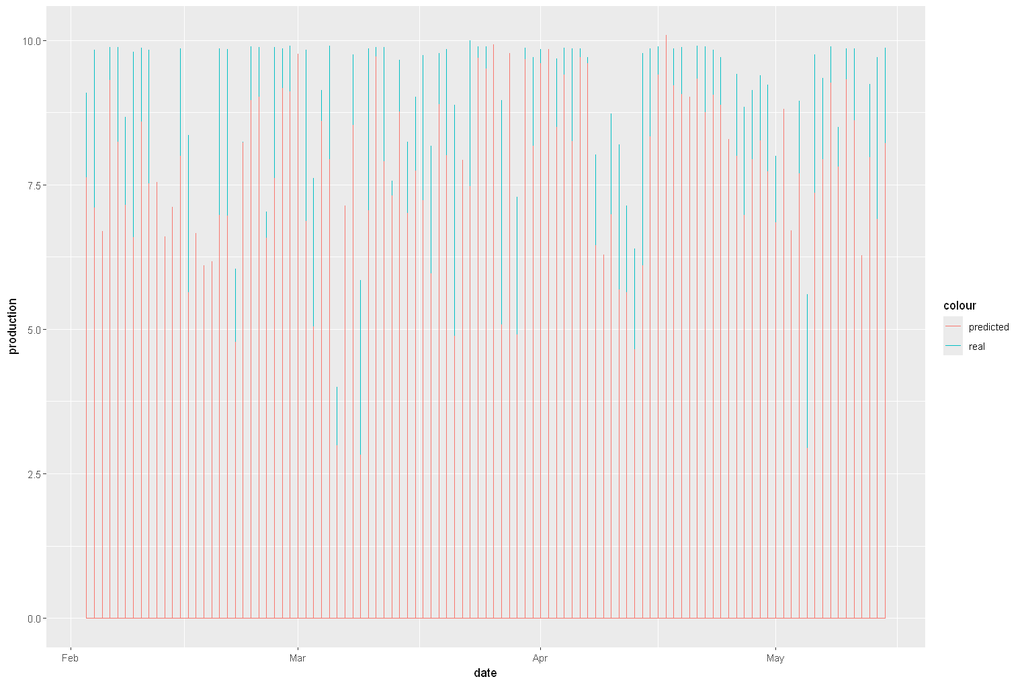

```
	Ljung-Box test

data:  Residuals
Q* = 1426.1, df = 10, p-value < 2.2e-16

Model df: 0.   Total lags used: 10
```

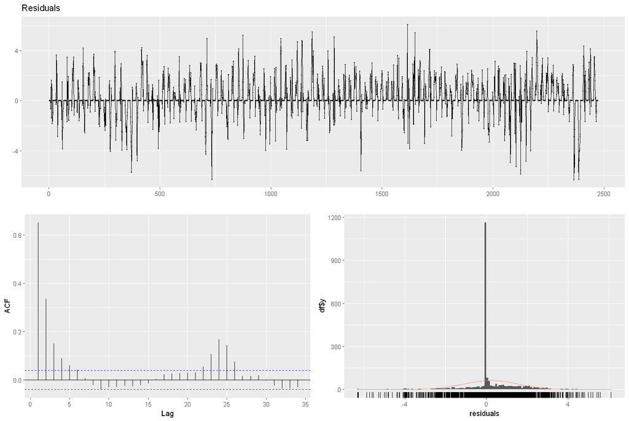

```r
ggplot(merged_data,aes(x=date)) + geom_line(aes(y=production,color='real')) + geom_line(aes(y=predicted,color='predicted'))

setDT(merged_data)
merged_data[,residual:=production-predicted]
checkresiduals(merged_data$residual)
```

```r
accu7 <- accu("Final Model (3rd model with all hours)", merged_data$production, merged_data$predicted)
comparisons <- rbind(comparisons, accu7)
comparisons
```

A data.frame: 8 × 11

| model <chr> | n <int> | mean <dbl> | sd <dbl> | CV <dbl> | FBias <dbl> | MAPE <dbl> | RMSE <dbl> | MAD <dbl> | MADP <dbl> | WMAPE <dbl> |
| --- | --- | --- | --- | --- | --- | --- | --- | --- | --- | --- |
| 0. Baseline-LM | 1269 | 5.060165 | 3.389830 | 0.6699049 | 0.1048254650 | 4469.314 | 1.993499 | 1.5641154 | 0.3091036 | 0.3091036 |
| 1. Lasso(1sd)-LM | 1269 | 5.060165 | 3.389830 | 0.6699049 | 0.1088095279 | 4058.146 | 1.994581 | 1.5732406 | 0.3109070 | 0.3109070 |
| 2. Lasso(1sd) - LM_lag10 (IM) | 1262 | 5.044160 | 3.386026 | 0.6712765 | 0.0745083684 | 4407.538 | 1.908707 | 1.5053248 | 0.2984292 | 0.2984292 |
| 3. Lasso(1sd)-LM_lag24_lag36 | 1236 | 5.055283 | 3.381461 | 0.6688964 | 0.0809165157 | 4201.848 | 1.906118 | 1.4935608 | 0.2954455 | 0.2954455 |
| 4. Lasso(3sd)-LM_lag24_lag36 | 1236 | 5.055283 | 3.381461 | 0.6688964 | 0.0991611324 | 4422.851 | 1.946731 | 1.5493871 | 0.3064887 | 0.3064887 |
| 5. ARIMA for each hour | 1236 | 5.055283 | 3.381461 | 0.6688964 | 0.0007428499 | 6006.657 | 2.373454 | 1.7523747 | 0.3466422 | 0.3466422 |
| 6. ARIMA for overall (IM) | 1236 | 5.055283 | 3.381461 | 0.6688964 | 0.0012032262 | 3022.291 | 1.935345 | 1.4082776 | 0.2785754 | 0.2785754 |
| Final Model (3rd model with all hours) | 2472 | 2.537112 | 3.473294 | 1.3689953 | 0.0843471019 | 2100.963 | 1.349820 | 0.7562505 | 0.2980754 | 0.2980754 |